# Bay of Biscay and the Iberian Coast

ICES 2024

[figure not shown]

**Information on the distribution, intensity, impact and economic value of mobile bottom contacting gear (MBCG) fisheries within the Bay of Biscay and the Iberian Coast area and associated subdivisions, and estimated consequences and costs (landings weight, landings value) of reducing their relative extent.**

## Bay of Biscay and the Iberian Coast

### Summary

**Geographic scope:** The assessment in this interactive document covers EU waters of depths shallower than 800 m in the MSFD subdivisions associated with the Bay of Biscay and the Iberian Coast area. EU waters are the waters defined by EU Member States, in this area, for MSFD implementation purposes (Figure E1).

**Spatial scales of analyses:** Analyses are presented by MSFD subdivision, MSFD broad habitat type (BHT) and for depth strata 0‒200 m, 200‒400 m, and 400‒800 m. The 0.05° × 0.05° c-squares (hereafter c-squares) were allocated to subdivisions based on centroid positions. Mean depths in c-squares were used to allocate c-squares to depth strata. For the Baltic Sea area, the subdivisions are as used in the ICES 2021 advice (ICES, 2021) and based on the HELCOM sub-basins (HELCOM, 2013). For the Greater North Sea, Celtic Seas and Bay of Biscay and the Iberian Coast areas, the subdivisions used are the OSPAR benthic habitat assessment area units (OSPAR, 2022), as used in the OSPAR 2023 Quality Status Report (OSPAR, 2023). The extent of BHTs, as defined under the MSFD, is determined per c-square.

Values of pressure indicators (I‒1 to I‒5) and impact indicators (I‒6a, I‒6b, I‒7a, and I‒7b) by depth strata (Table 1) provide information on the distribution, intensity, and impact of MBCG fisheries. The indicators are described in the “Essential information” tab in this document.

For depths of 0‒200 m, 67.3% of the area is fished with MBCG per year (I‒3). However, 90% of the total MBCG swept area is concentrated in an annual average of 45.7% of the Bay of Biscay and the Iberian Coast area. Nineteen point one per cent of the area at these depths was not fished with MBCG at all from 2017‒2022, based on the data submissions received. For depths of 0‒200m, MBCG fishing was estimated to reduce the total biomass of benthic fauna by 14.8% (I‒6a) and reduce the total biomass of sensitive fauna by 19% (I‒6b). Within this depth strata, the depletion of benthic fauna was less than 20% in 77% (I‒7a) of the area. For sensitive fauna the corresponding area was 68.6% (I‒7b). The heterogeneous distributions of annual mean fishing intensity (swept area ratio [SAR]), annual mean total landings values (euros) and weight (kg), and seabed sensitivity (as estimated median longevity of the benthic fauna), are illustrated in Figure 1. The distributions of the fishing intensity and the seabed sensitivity account for the values of pressure and impact indicators reported in Table 1.

Small-scale fisheries, defined as vessels < 12 m in overall length deploying MBCG, operate in the Bay of Biscay and the Iberian Coast area as well. As these are not required to carry VMS by the EU Control Regulation (EU, 2009), their coverage in the VMS data submissions is unknown. The EU Fisheries Dependent Information (FDI) data does report on small-scale fisheries effort in kW × fishing days. However, the FDI reporting units differ from the subdivisions, BHTs, and depth strata used in these analyses. The correspondence between subdivisions and FDI reporting regions is illustrated in Figure E1. The incomplete data for small-scale fisheries results in underestimates of fishing intensity and impact, especially in inshore areas. In the Bay of Biscay and the Iberian Coast area the proportion of the total kW × fishing days of MBCG fishing attributed to small-scale fisheries (Table 2) varies from 1 - 23% between FAO regions.

**References:**

EU Council. 2009. Council Regulation (EC) No 1224/2009 of 20 November 2009 establishing a Community control system for ensuring compliance with the rules of the Common Fisheries Policy amending Regulations (EC) No 847/96, (EC) No 2371/2002, (EC) No 811/2004, (EC) No 768/2005, (EC) No 2115/2005, (EC) No 2166/2005, (EC) No 388/2006, (EC) No 509/2007, (EC) No 676/2007, (EC) No 1098/2007, (EC) No 1300/2008, (EC) No 1342/2008 and repealing Regulations (EEC) No 2847/93, (EC) No 1627/94 and (EC) No 1966/2006. Official Journal of the European Union L343, 1−50. http://data.europa.eu/eli/reg/2009/1224/oj

HELCOM. 2013. HELCOM Monitoring and Assessment Strategy. https://helcom.fi/wp-content/uploads/2020/02/Monitoring-and-assessment-strategy.pdf

ICES. 2021. ICES advice to the EU on how management scenarios to reduce mobile bottom fishing disturbance on seafloor habitats affect fisheries landing and value. In Report of the ICES Advisory Committee, 2021. ICES Advice 2021. sr.2021.08. https://doi.org/10.17895/ices.advice.8191

OSPAR. 2022. OSPAR Extent of Physical Disturbance to Benthic Habitats Assessment Units. https://odims.ospar.org/en/submissions/ospar_phys_dist_habs_au_2022_06/

OSPAR. 2023. OSPAR Quality Status Report. https://oap.ospar.org/en/ospar-assessments/quality-status-reports/qsr-2023/

#### Table 1

**Table 1. Values of pressure and impact indicators for 2017‒2022 for three depth strata in the Bay of Biscay and the Iberian Coast area. Values of I‒1, I‒2, I‒3, I‒4, I‒6a, I‒6b, I‒7a and I‒7b are annual means and I‒5 is evaluated over the six years. Descriptions of the pressure and impact indicators are provided in the ‘Essential Information’ Table E1 in this document.**

| Indicators | 0 to 200 m | 200 to 400 m | 400 to 800 m |
| --- | --- | --- | --- |
| I‒1: Average fishing intensity | 3.02 | 3.01 | 0.73 |
| I‒2: Proportion of area fished, evaluated at c-square scale (%) | 80.90 | 88.00 | 67.80 |
| I‒3: Proportion of area fished (%) | 67.30 | 72.80 | 30.20 |
| I‒4: Smallest proportion of area with 90% of fishing intensity, evaluated at c-square scale (%) | 45.70 | 47.40 | 23.70 |
| I‒5: Proportion of area persistently unfished, evaluated at c-square scale (%) | 19.10 | 12.00 | 32.20 |
| I‒6a: Average PD impact | 14.80 | 14.00 | 4.40 |
| I‒6b: Average PD-sens impact | 19.00 | 17.30 | 5.50 |
| I‒7a: Proportion of area with PD impact < 0.2, evaluated at c-square scale (%) | 77.00 | 77.20 | 93.40 |
| I‒7b: Proportion of area with PD-sens impact < 0.2, evaluated at c-square scale (%) | 68.60 | 71.50 | 91.30 |

#### Figure 1

**Figure 1. Geographic distribution of fishing intensity (swept area ratio), seabed sensitivity (community longevity), total landings value, and total landings weight from mobile bottom-contacting gear (MBCG) in the Bay of Biscay and the Iberian Coast area. The maps of swept area ratio, landings value, and landings weight show annual means evaluated at the c-square scale.**

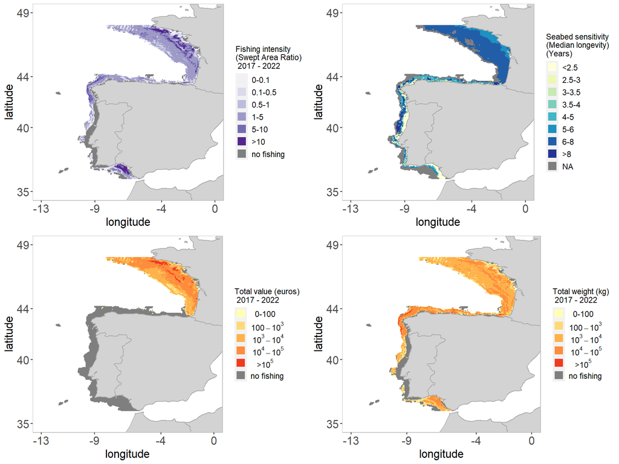

#### Table 2

**Table 2. Contribution of small-scale fisheries (vessels < 12 m overall length) to total fishing effort (kW × fishing days) in the Bay of Biscay and the Iberian Coast area. The table shows the total fishing effort (kW × fishing days) by FAO region over the assessment period, and the mean contribution (%) and observed range in contribution (%) of small-scale MBCG fisheries.**

| FAO region code | FAO region name | Total fishing effort (kW × Fishing days) | Mean contribution SSF (%) | Observed range SSF contribution (%) [min - max] |
| --- | --- | --- | --- | --- |
| 27.8.a | Bay of Biscay - North | 10411305 | 23.2 | [21 - 24] |
| 27.8.b | Bay of Biscay - Central | 3154505 | 12.3 | [11 - 14] |
| 27.8.c | Bay of Biscay - South | 4221423 | 2.7 | [0 - 5] |
| 27.8.d | Bay of Biscay - Offshore | 125039 | 1.0 | [0 - 2] |
| 27.9.a | Portuguese Waters - East | 7567817 | 23.2 | [2 - 34] |

### Fishing intensity

The extent and relative abundance of BHTs in the Bay of Biscay and the Iberian Coast area are presented in Table 3. This table also presents landings weight and landings value and the intensity of MBCG fisheries operating in these habitats. Note that fishing data is only available at the c-square scale and is assumed to be uniformly distributed over all habitat types present in a c-square. Each habitat type present is proportionally assigned the fishing data registered in a c-square.

Temporal variation of the pressure indicators I−1, I−3, and I−4 are shown in Figure 2 for the Bay of Biscay and the Iberian Coast area.

#### Table 3

**Table 3. Extent (in km<sup>2</sup> and %) of broad habitat types in the Bay of Biscay and the Iberian Coast area, and mean annual estimates of MBCG fishing intensity, landings weight, and landings value. In addition, estimates of the average annual proportion of the fished extent, the smallest proportion of the habitat extent affected by 90% of the fishing effort, and the proportion of extent persistently unfished are provided.**

| MSFD broad habitat type | Extent of habitat (×1000 km<sup>2</sup>) | Relative habitat extent (%) | Landings (×1000 tonnes) | Value (×10<sup>6</sup> euro) | Swept area (×1000 km<sup>2</sup>) | Average fishing intensity (I‒1) | Average annual extent fished (%) | Smallest proportion of extent with 90% of fishing effort (%) | Percentage extent persistently unfished (%) |
| --- | --- | --- | --- | --- | --- | --- | --- | --- | --- |
| Offshore circalittoral sand | 34.97 | 20.4 | 15.64 | NA | 84.68 | 2.42 | 84.6 | 68.7 | 3.7 |
| Offshore circalittoral mud | 31.48 | 18.3 | 14.89 | NA | 121.86 | 3.87 | 74.6 | 54.5 | 16.4 |
| Upper bathyal sediment | 26.40 | 15.4 | 21.61 | NA | 53.25 | 2.02 | 51.4 | 35.3 | 19.7 |
| Circalittoral sand | 16.24 | 9.5 | 3.75 | NA | 46.18 | 2.84 | 59.7 | 44.3 | 26.5 |
| Offshore circalittoral coarse sediment | 11.92 | 6.9 | 3.67 | NA | 33.49 | 2.81 | 90.8 | 74.8 | 1.1 |
| Circalittoral coarse sediment | 8.54 | 5.0 | 4.24 | NA | 51.68 | 6.05 | 83.8 | 61.2 | 3.9 |
| Upper bathyal sediment or Upper bathyal rock and biogenic reef | 8.40 | 4.9 | 0.50 | NA | 3.80 | 0.45 | 22.1 | 21.7 | 40.9 |
| Offshore circalittoral rock and biogenic reef | 7.00 | 4.1 | 2.40 | NA | 10.70 | 1.53 | 57.7 | 50.5 | 18.1 |
| Circalittoral rock and biogenic reef | 6.88 | 4.0 | 0.66 | NA | 4.21 | 0.61 | 24.6 | 23.2 | 47.1 |
| Circalittoral mud | 6.26 | 3.6 | 2.10 | NA | 31.11 | 4.97 | 48.4 | 27.9 | 32.9 |
| Offshore circalittoral mixed sediment | 3.36 | 2.0 | 2.34 | NA | 22.13 | 6.59 | 80.5 | 60.9 | 14.2 |
| Circalittoral mixed sediment | 2.97 | 1.7 | 0.20 | NA | 2.72 | 0.92 | 11.9 | 8.3 | 79.3 |
| Infralittoral sand | 1.91 | 1.1 | 0.11 | NA | 0.94 | 0.49 | 10.0 | 5.9 | 64.5 |
| Infralittoral rock and biogenic reef | 1.65 | 1.0 | 0.02 | NA | 0.15 | 0.09 | 5.9 | 12.4 | 66.1 |
| Upper bathyal rock and biogenic reef | 1.23 | 0.7 | 0.89 | NA | 1.54 | 1.26 | 40.6 | 34.0 | 37.6 |
| Infralittoral mud | 0.56 | 0.3 | 0.02 | NA | 0.11 | 0.21 | 5.9 | 4.7 | 62.1 |
| Lower bathyal sediment | 0.50 | 0.3 | 0.03 | NA | 0.05 | 0.10 | 7.4 | 26.7 | 28.3 |
| Infralittoral coarse sediment | 0.45 | 0.3 | 0.02 | NA | 0.12 | 0.27 | 11.4 | 15.2 | 41.6 |
| Lower bathyal sediment or Lower bathyal rock and biogenic reef | 0.34 | 0.2 | 0.01 | NA | 0.02 | 0.07 | 6.4 | 34.6 | 43.2 |
| Unknown | 0.31 | 0.2 | 0.14 | NA | 0.15 | 0.48 | 27.3 | 27.8 | 56.9 |
| Infralittoral mixed sediment | 0.30 | 0.2 | 0.02 | NA | 0.20 | 0.66 | 15.2 | 8.8 | 52.3 |
| Lower bathyal rock and biogenic reef | 0.04 | 0.0 | 0.00 | NA | 0.00 | 0.04 | 3.7 | NA | 30.5 |
| Abyssal | 0.01 | 0.0 | 0.00 | NA | 0.00 | 0.01 | 1.3 | NA | 3.4 |

#### Figure 2

**Figure 2. Temporal variation of the pressure indicators I‒1, I‒3 and I‒4 in the Bay of Biscay and the Iberian Coast area. Descriptions of the pressure indicators are provided in the ‘Essential Information’ Table E1 in this document.**

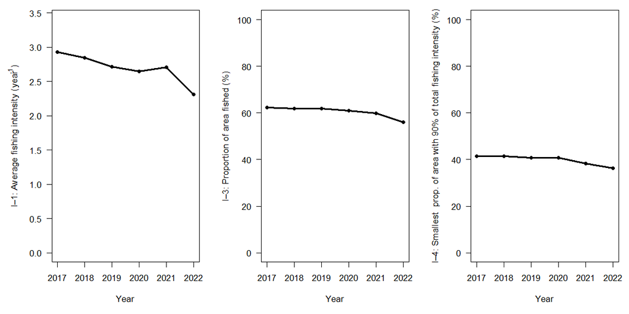

### Fishing by métier

Relationships between swept area and the landings weight and landings value of the métiers show the landings and economic returns as a function of swept area (Table 4). The most active métier within the Bay of Biscay and the Iberian Coast area is OT_DMF. This métier lands 117.7 kg of fish per km<sup>2</sup> swept area.

The métier with the highest landing per swept area is DRB_MOL.

#### Table 4

**Table 4. Landings weight and value by métier and their relationship with swept area in the Bay of Biscay and the Iberian Coast area.**

|  | OT_DMF | OT_CRU | OT_MI | SDN_DMF | TBB_DMF | OT_SPF | DRB_MOL |
| --- | --- | --- | --- | --- | --- | --- | --- |
| Area swept (×1000 km<sup>2</sup>) | 201.20 | 146.04 | 68.44 | 49.68 | 2.33 | 1.76 | 0.02 |
| Landings (×1000 tonnes) | 23.68 | 10.96 | 35.23 | 1.79 | 0.49 | 0.99 | 0.11 |
| Value (×10<sup>6</sup> euro) | NA | NA | NA | NA | NA | NA | NA |
| Landings / Area swept (kg/km<sup>2</sup>) | 117.70 | 75.04 | 514.76 | 36.00 | 211.74 | 564.64 | 5211.92 |
| Value / Area swept (euro/km<sup>2</sup>) | NA | NA | NA | NA | NA | NA | NA |

### Core fishing grounds

**Note that only the Gulf of Biscay is considered in the identification of the core fishing grounds, due to missing landings values in the other subdivisions.**

Core fishing grounds are defined as the smallest area yielding 90% of the landings value, evaluated annually at the c-square scale. The spatial stability of core fishing grounds over the assessment period 2017−2022 is described as the number of years a c-square is identified as a core fishing ground. This spatial extent and stability of the core fishing grounds varies among métiers (Figures 3 and 4).

Overall, there is considerable variation in the stability of core fishing grounds among métiers. This is expected to be a consequence of interannual movements of fishing locations because of the habitat affinity of the variety of fish and shellfish targeted by different métiers (Table 5 in the main advice document) and the effects of economic and regulatory factors.

#### Figure 3

**Figure 3. Spatial stability of core MBCG fishing grounds, presented as the number of years a c-square is identified as a core fishing ground (smallest area yielding 90% of the landings value) per métier for the Gulf of Biscay subdivision. Only métiers that were active within > 50 unique c-squares during the assessment period are included. The numbers between brackets show the proportion of fished extent compared to the overall assessed area extent.**

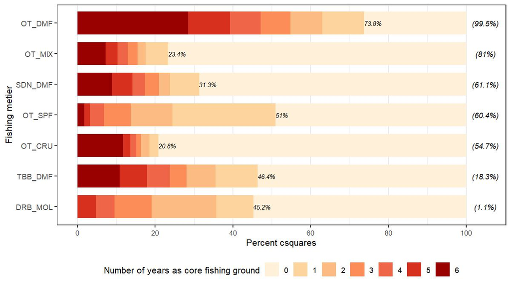

#### Figure 4

**Figure 4. Spatial distribution of the stability of the core MBCG fishing grounds, presented as the number of years a c-square is identified as a core fishing ground (smallest area yielding 90% of the landings value) per métier for the Gulf of Biscay subdivision. Only métiers that were active within > 50 unique c-squares during the assessment period are included.**

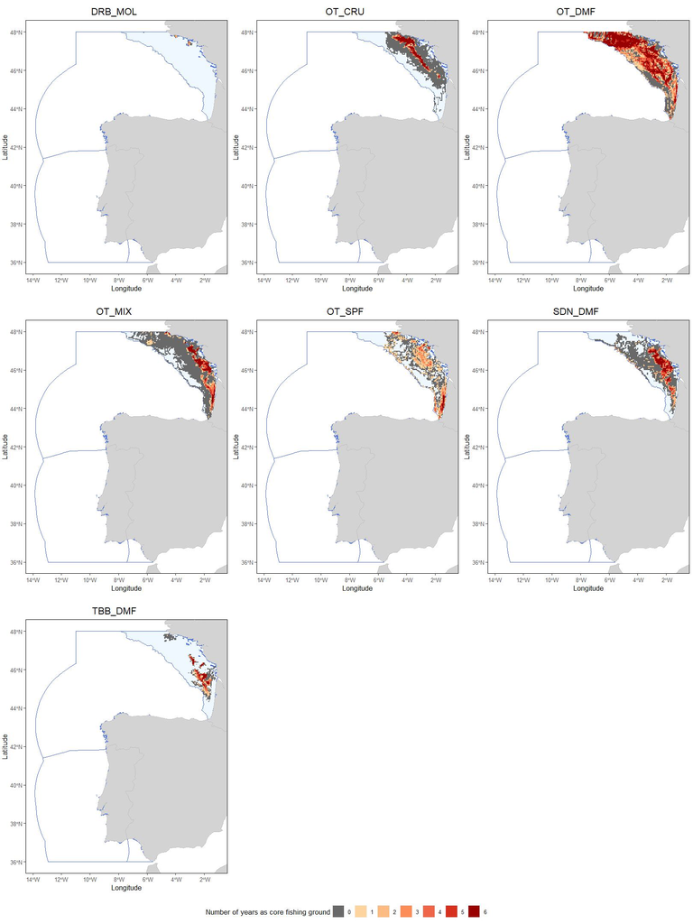

### Impact

Fishing impact, as assessed with the PD indicator (I−6a) and the PD-sens indicator (I−6b), results from the fishing intensity for MBCG métiers and the median longevity of the benthic fauna (Figure 1) as well as métier-specific depletion rates per trawl pass (Table 5 in the main advice document). The PD-sens indicator only considers sensitive fauna and shows greater impacts than the PD indicator (Figures 5 and 6).

The spatial distribution of the fishing impact in the Bay of Biscay and the Iberian Coast area is shown in Figure 5. When based on the PD indicator, fishing impact is 0.14 on average (I−6a), with 78% of the area having a fishing impact below 0.2 (I−7a; Figure 6). For the PD-sens indicator, the average impact is 0.18 (I−6b), with 69% of the area having less impact than 0.2 (I−7b; Figure 6).

For the OT_DMF métier, which accounts for the largest proportion of swept area (Table 4), landing weight is 63.3 tonnes per unit of PD impact. Similarly, landing weight is 48.6 tonnes per unit of PD-sens impact (Table 5). The métier with the highest landings weight per unit impact is OT_MIX (111.8 tonnes), .

Métier-related impacts, as measured with the PD and PD-sens indicators, vary among BHTs because of variations in fishing intensity, seabed sensitivity (Figure 1), and the depletion rate of the specific métier (Table 5 in the main advice document; Figure 7). The largest PD and PD sens impacts in the Bay of Biscay and the Iberian Coast area are attributed to the OT_CRU métier fishing on Offshore circalittoral mud.

#### Figure 5

**Figure 5. The spatial distribution of MBCG fisheries impact in the Bay of Biscay and the Iberian Coast area, as assessed with the PD indicator (I‒6a) and PD-sens indicator (I‒6b), shown as annual means for the assessment period, evaluated at the c-square scale. Descriptions of the impact indicators are provided in the ‘Essential Information’ Table E1 in this document.**

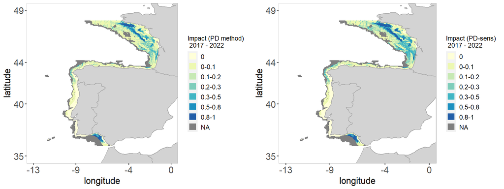

#### Figure 6

**Figure 6. Temporal variation in values of the PD indicator (I‒6a), PD-sens indicator (I‒6b), proportion of the extent with PD impact < 0.2 (I‒7a) and proportion of extent with PD-sens impact < 0.2 (I‒7b), shown for the overall area and for the four most extensive broad habitat types separately in the Bay of Biscay and the Iberian Coast area. Descriptions of the impact indicators are provided in the ‘Essential Information’ Table E1 in this document.**

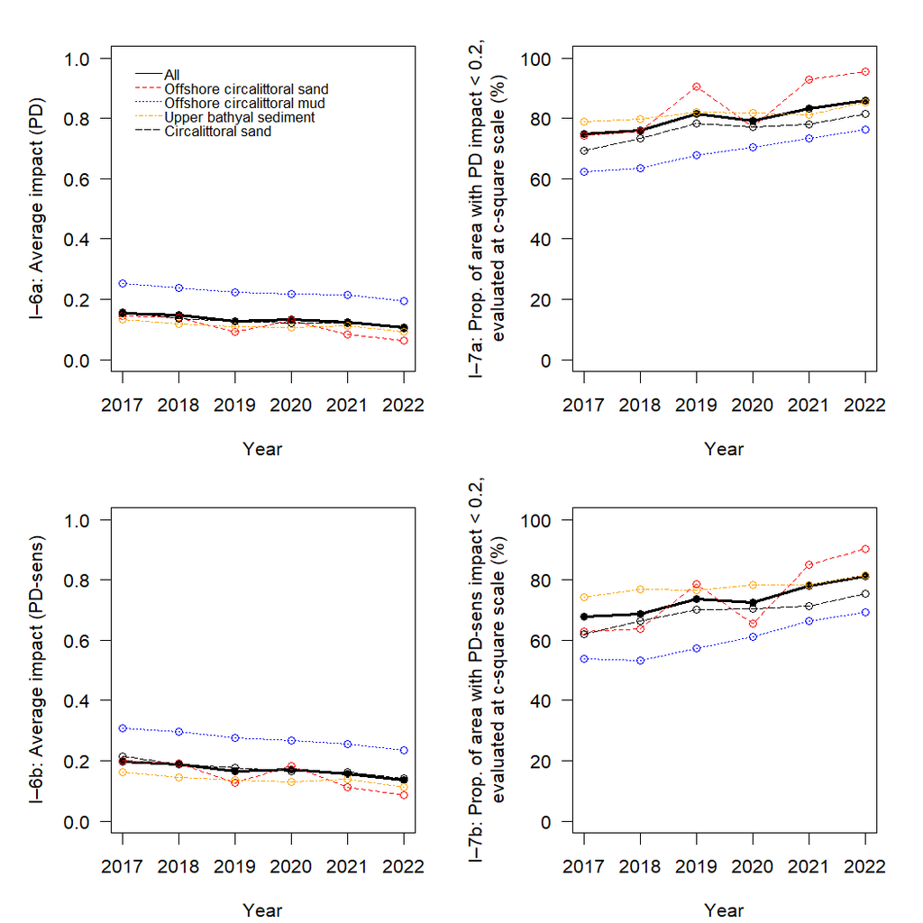

#### Table 5

**Table 5. Métier-specific landings weight and value per unit PD or PD-sens impact in the Bay of Biscay and the Iberian Coast area.**

|  | OT_DMF | OT_CRU | OT_MI | SDN_DMF | TBB_DMF | OT_SPF | DRB_MOL |
| --- | --- | --- | --- | --- | --- | --- | --- |
| Landings (tonnes)/PD impact | 63.3 | 21.1 | 111.8 | 64.7 | 24.2 | 84.4 | 35.8 |
| Value (×1000 euro)/PD impact | NA | NA | NA | NA | NA | NA | NA |
| Landings (tonnes)/PD-sens impact | 48.6 | 18.3 | 85.7 | 46.2 | 17.2 | 81.7 | 44.2 |
| Value (×1000 euro)/PD-sens impact | NA | NA | NA | NA | NA | NA | NA |

#### Figure 7

**Figure 7. Métier-related impacts, reported as annual means of the PD indicator (I‒6a, top) and PD-sens indicator (I‒6b, bottom), on the four most extensive broad habitat types in the Bay of Biscay and the Iberian Coast area.**

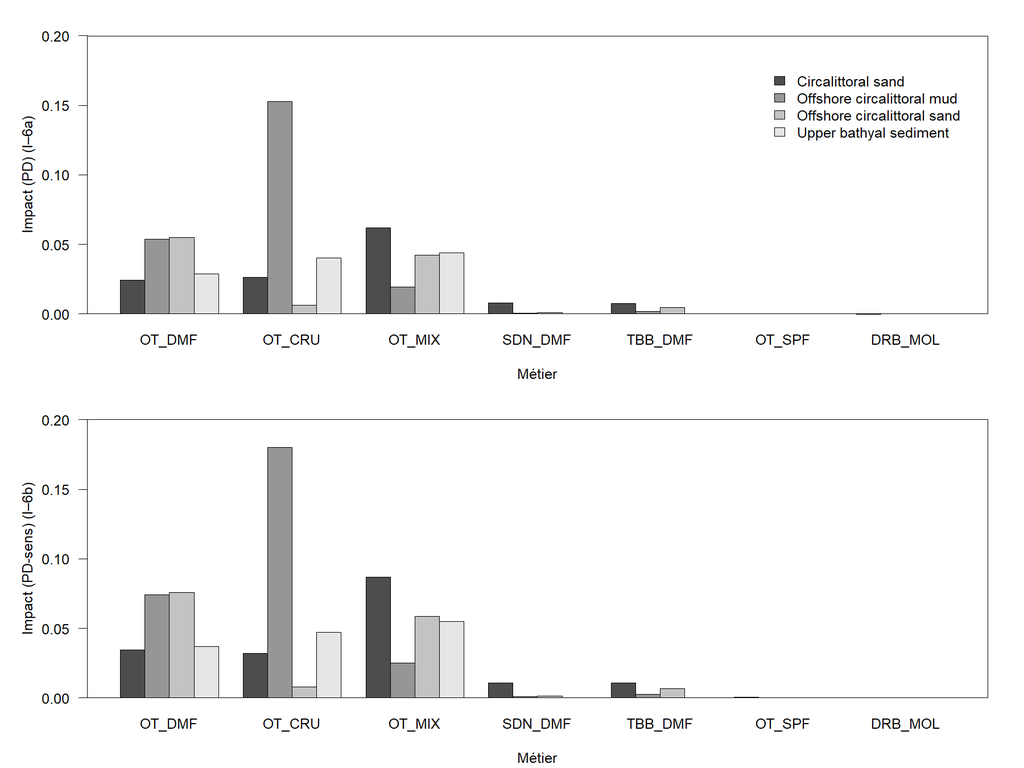

### Scenarios

#### Footprint reduction

The fishing footprint reduction scenarios illustrate the effects of stepwise MBCG fisheries exclusion from specified proportions of each BHT within the Bay of Biscay and the Iberian Coast area. The stepwise exclusion is conducted in 10% increments, ranging from 10% to 90%. In each successive increment, the c-squares containing the least MBCG swept area are excluded. The resulting reduction in swept area (Table 6), landings weight (Table 7), and landings value (Table 8) is presented for the prevailing BHTs combined and for each type separately.

For example, the analysis shows that the exclusion of MBCG from 30% of all prevailing BHTs types is affecting 4.0% of the footprint (Table 6), 4.8% of the landings weight (Table 7),. No estimation could be provided for the loss in landings value (Table 8). In this example, the pattern reflects the extent to which MBCG fishing activity is concentrated in core areas, with relatively low effort and landings in peripheral areas.

##### Table 6: Effort

**Table 6. The effects of stepwise exclusion of all MBCG fisheries from a specified proportion of a MSFD broad habitat type within the Bay of Biscay and the Iberian Coast area, on swept area (presented as % of total swept area within that habitat type). The stepwise exclusion is conducted in 10% increments, and within each successive increment from 10% to 90% the c-squares with the lowest recorded rank MBCG swept area are excluded. Note that the top row shows the total estimate for all habitats combined.**

| MSFD broad habitat type | Extent of habitat (×1000 km<sup>2</sup>) | Total area swept (×1000 km<sup>2</sup> | 10% | 20% | 30% | 40% | 50% | 60% | 70% | 80% | 90% |
| --- | --- | --- | --- | --- | --- | --- | --- | --- | --- | --- | --- |
| total | 171.68 | 100 | 0.3 | 1.5 | 4.0 | 8.3 | 14.4 | 22.1 | 31.7 | 44.7 | 63.1 |
| Offshore circalittoral sand | 34.97 | 84.68 | 0.6 | 4.0 | 9.3 | 16.2 | 25.1 | 35.2 | 47.0 | 60.5 | 77.1 |
| Offshore circalittoral mud | 31.48 | 121.86 | 0.0 | <0.1 | 2.2 | 6.7 | 13.3 | 21.3 | 30.4 | 41.9 | 58.6 |
| Upper bathyal sediment | 26.4 | 53.25 | 0.0 | <0.1 | 0.2 | 0.9 | 3.0 | 7.2 | 15.0 | 28.6 | 51.5 |
| Circalittoral sand | 16.24 | 46.18 | 0.0 | 0.0 | <0.1 | 1.6 | 6.9 | 14.7 | 25.1 | 38.5 | 58.4 |
| Offshore circalittoral coarse sediment | 11.92 | 33.49 | 3.1 | 7.8 | 12.8 | 19.6 | 27.3 | 36.0 | 46.2 | 57.7 | 72.5 |
| Circalittoral coarse sediment | 8.54 | 51.68 | 0.1 | 1.4 | 4.9 | 11.6 | 19.9 | 28.7 | 39.1 | 52.4 | 69.4 |
| Upper bathyal sediment or Upper bathyal rock and biogenic reef | 8.4 | 3.8 | 0.0 | 0.0 | 0.3 | 1.7 | 4.4 | 8.5 | 16.5 | 28.4 | 52.6 |
| Offshore circalittoral rock and biogenic reef | 7 | 10.7 | 0.0 | <0.1 | 1.2 | 5.2 | 12.0 | 21.5 | 34.1 | 51.3 | 70.5 |
| Circalittoral rock and biogenic reef | 6.88 | 4.21 | 0.0 | 0.0 | 0.0 | <0.1 | 0.8 | 3.5 | 8.3 | 20.1 | 43.0 |
| Circalittoral mud | 6.26 | 31.11 | 0.0 | 0.0 | 0.0 | <0.1 | 0.7 | 3.0 | 8.8 | 22.4 | 47.4 |
| Offshore circalittoral mixed sediment | 3.36 | 22.13 | 0.0 | 0.4 | 4.4 | 10.9 | 17.5 | 26.9 | 38.1 | 54.6 | 76.3 |
| Circalittoral mixed sediment | 2.97 | 2.72 | 0.0 | 0.0 | 0.0 | 0.0 | 0.0 | 0.0 | 0.0 | <0.1 | 4.8 |
| Infralittoral sand | 1.91 | 0.94 | 0.0 | 0.0 | 0.0 | 0.0 | 0.0 | <0.1 | 0.3 | 1.2 | 6.6 |
| Infralittoral rock and biogenic reef | 1.65 | 0.15 | 0.0 | 0.0 | 0.0 | 0.0 | 0.0 | <0.1 | 1.4 | 5.4 | 22.1 |
| Upper bathyal rock and biogenic reef | 1.23 | 1.54 | 0.0 | 0.0 | 0.0 | 0.2 | 1.7 | 7.5 | 20.9 | 41.5 | 67.4 |
| Infralittoral mud | 0.56 | 0.11 | 0.0 | 0.0 | 0.0 | 0.0 | 0.0 | <0.1 | 0.7 | 1.6 | 3.4 |
| Lower bathyal sediment | 0.5 | 0.05 | 0.0 | 0.0 | 0.0 | <0.1 | 1.4 | 2.9 | 9.2 | 16.3 | 32.3 |
| Infralittoral coarse sediment | 0.45 | 0.12 | 0.0 | 0.0 | 0.0 | <0.1 | 0.4 | 1.7 | 4.0 | 7.1 | 13.6 |
| Lower bathyal sediment or Lower bathyal rock and biogenic reef | 0.34 | 0.02 | 0.0 | 0.0 | <0.1 | 7.7 | 7.7 | 15.1 | 17.2 | 25.0 | 52.3 |
| Unknown | 0.31 | 0.15 | <0.1 | 2.9 | 10.7 | 16.8 | 23.9 | 39.2 | 72.4 | 100.0 | 100.0 |
| Infralittoral mixed sediment | 0.3 | 0.2 | 0.0 | 0.0 | 0.0 | 0.0 | <0.1 | <0.1 | 0.3 | 3.4 | 22.3 |
| Abyssal | 0.01 | 0 | 0.0 | 0.0 | 0.0 | 0.0 | 43.9 | 43.9 | 100.0 | 100.0 | 100.0 |

##### Table 7: Landings weight

**Table 7. The effects of stepwise exclusion of all MBCG fisheries from a specified proportion of a MSFD broad habitat type within the Bay of Biscay and the Iberian Coast area, on landings weight (presented as % of total landings weight within that habitat type). The stepwise exclusion is conducted in 10% increments, and within each successive increment from 10% to 90% the c-squares with the lowest recorded rank MBCG swept area are excluded. Note that the top row shows the total estimate for all habitats combined.**

| MSFD broad habitat type | Extent of habitat (×1000 km<sup>2</sup>) | Total landings weight (×1000 kg) | 10% | 20% | 30% | 40% | 50% | 60% | 70% | 80% | 90% |
| --- | --- | --- | --- | --- | --- | --- | --- | --- | --- | --- | --- |
| Total | 171.68 | 72428.5 | 0.5 | 2.0 | 4.8 | 9.6 | 16.3 | 24.0 | 33.5 | 47.1 | 66.5 |
| Offshore circalittoral sand | 34.97 | 15532.9 | 0.7 | 4.7 | 10.4 | 19.5 | 29.1 | 39.8 | 51.1 | 64.5 | 80.7 |
| Offshore circalittoral mud | 31.48 | 14864.2 | 0.0 | 0.1 | 3.3 | 9.8 | 19.8 | 30.5 | 42.0 | 55.1 | 76.6 |
| Upper bathyal sediment | 26.4 | 21546.3 | 0.0 | <0.1 | 0.1 | 0.6 | 2.1 | 4.8 | 10.9 | 24.8 | 46.6 |
| Circalittoral sand | 16.24 | 3737.6 | 0.0 | 0.0 | 0.5 | 3.9 | 13.4 | 23.0 | 33.4 | 45.6 | 64.0 |
| Offshore circalittoral coarse sediment | 11.92 | 3662.3 | 6.5 | 14.5 | 21.0 | 29.2 | 38.3 | 48.6 | 60.9 | 72.6 | 84.2 |
| Circalittoral coarse sediment | 8.54 | 4241.9 | 0.4 | 3.1 | 7.2 | 13.4 | 20.7 | 28.2 | 36.5 | 48.9 | 63.6 |
| Upper bathyal sediment or Upper bathyal rock and biogenic reef | 8.4 | 162.1 | 0.0 | 0.0 | 0.5 | 2.6 | 4.9 | 9.3 | 21.8 | 32.6 | 69.2 |
| Offshore circalittoral rock and biogenic reef | 7 | 2252.9 | 0.0 | 0.1 | 1.4 | 7.0 | 14.9 | 26.1 | 42.3 | 62.3 | 83.0 |
| Circalittoral rock and biogenic reef | 6.88 | 637.9 | 0.0 | 0.0 | 0.0 | <0.1 | 1.2 | 5.1 | 11.8 | 30.8 | 62.2 |
| Circalittoral mud | 6.26 | 2087.5 | 0.0 | 0.0 | 0.0 | 0.4 | 2.5 | 5.9 | 11.9 | 25.4 | 49.4 |
| Offshore circalittoral mixed sediment | 3.36 | 2335.5 | 0.0 | 0.8 | 8.4 | 17.0 | 28.9 | 39.9 | 52.4 | 66.2 | 82.8 |
| Circalittoral mixed sediment | 2.97 | 204.3 | 0.0 | 0.0 | 0.0 | 0.0 | 0.0 | 0.0 | 0.0 | <0.1 | 7.3 |
| Infralittoral sand | 1.91 | 105.4 | 0.0 | 0.0 | 0.0 | 0.0 | 0.0 | <0.1 | 1.8 | 14.5 | 33.0 |
| Infralittoral rock and biogenic reef | 1.65 | 19.8 | 0.0 | 0.0 | 0.0 | 0.0 | 0.0 | 0.2 | 5.2 | 11.6 | 38.8 |
| Upper bathyal rock and biogenic reef | 1.23 | 869.6 | 0.0 | 0.0 | 0.0 | <0.1 | 1.3 | 6.0 | 15.0 | 35.2 | 64.0 |
| Infralittoral mud | 0.56 | 16.6 | 0.0 | 0.0 | 0.0 | 0.0 | 0.0 | 0.3 | 6.8 | 23.4 | 38.6 |
| Lower bathyal sediment | 0.5 | 26.4 | 0.0 | 0.0 | 0.0 | <0.1 | 0.8 | 1.5 | 5.8 | 10.7 | 36.2 |
| Infralittoral coarse sediment | 0.45 | 24.7 | 0.0 | 0.0 | 0.0 | <0.1 | 1.1 | 7.1 | 13.2 | 29.6 | 39.8 |
| Lower bathyal sediment or Lower bathyal rock and biogenic reef | 0.34 | 3.4 | 0.0 | 0.0 | 0.6 | 13.4 | 13.4 | 24.6 | 31.0 | 52.4 | 72.1 |
| Unknown | 0.31 | 73.2 | <0.1 | 0.9 | 2.3 | 2.9 | 4.0 | 7.1 | 50.4 | 100.0 | 100.0 |
| Infralittoral mixed sediment | 0.3 | 24.2 | 0.0 | 0.0 | 0.0 | 0.0 | 0.4 | 2.7 | 7.1 | 17.3 | 36.4 |
| Abyssal | 0.01 | 0 | 0.0 | 0.0 | 0.0 | 0.0 | 16.2 | 16.2 | 100.0 | 100.0 | 100.0 |

##### Table 8: Landings value

**Table 8. The effects of stepwise exclusion of all MBCG fisheries from a specified proportion of a MSFD broad habitat type within the Bay of Biscay and the Iberian Coast area, on landings value (presented as % of total landings value within that habitat type). The stepwise exclusion is conducted in 10% increments, and within each successive increment from 10% to 90% the c-squares with the lowest recorded rank MBCG swept area are excluded. Note that the top row shows the total estimate for all habitats combined.**

| MSFD broad habitat type | Extent of habitat (×1000 km<sup>2</sup>) | Total landings value (×1000 euro) | 10% | 20% | 30% | 40% | 50% | 60% | 70% | 80% | 90% |
| --- | --- | --- | --- | --- | --- | --- | --- | --- | --- | --- | --- |
| Total | 171.68 | NA | NA | NA | NA | NA | NA | NA | NA | NA | NA |
| Offshore circalittoral sand | 34.97 | NA | NA | NA | NA | NA | NA | NA | NA | NA | NA |
| Offshore circalittoral mud | 31.48 | NA | NA | NA | NA | NA | NA | NA | NA | NA | NA |
| Upper bathyal sediment | 26.4 | NA | NA | NA | NA | NA | NA | NA | NA | NA | NA |
| Circalittoral sand | 16.24 | NA | NA | NA | NA | NA | NA | NA | NA | NA | NA |
| Offshore circalittoral coarse sediment | 11.92 | NA | NA | NA | NA | NA | NA | NA | NA | NA | NA |
| Circalittoral coarse sediment | 8.54 | NA | NA | NA | NA | NA | NA | NA | NA | NA | NA |
| Upper bathyal sediment or Upper bathyal rock and biogenic reef | 8.4 | NA | NA | NA | NA | NA | NA | NA | NA | NA | NA |
| Offshore circalittoral rock and biogenic reef | 7 | NA | NA | NA | NA | NA | NA | NA | NA | NA | NA |
| Circalittoral rock and biogenic reef | 6.88 | NA | NA | NA | NA | NA | NA | NA | NA | NA | NA |
| Circalittoral mud | 6.26 | NA | NA | NA | NA | NA | NA | NA | NA | NA | NA |
| Offshore circalittoral mixed sediment | 3.36 | NA | NA | NA | NA | NA | NA | NA | NA | NA | NA |
| Circalittoral mixed sediment | 2.97 | NA | NA | NA | NA | NA | NA | NA | NA | NA | NA |
| Infralittoral sand | 1.91 | NA | NA | NA | NA | NA | NA | NA | NA | NA | NA |
| Infralittoral rock and biogenic reef | 1.65 | NA | NA | NA | NA | NA | NA | NA | NA | NA | NA |
| Upper bathyal rock and biogenic reef | 1.23 | NA | NA | NA | NA | NA | NA | NA | NA | NA | NA |
| Infralittoral mud | 0.56 | NA | NA | NA | NA | NA | NA | NA | NA | NA | NA |
| Lower bathyal sediment | 0.5 | NA | NA | NA | NA | NA | NA | NA | NA | NA | NA |
| Infralittoral coarse sediment | 0.45 | NA | NA | NA | NA | NA | NA | NA | NA | NA | NA |
| Lower bathyal sediment or Lower bathyal rock and biogenic reef | 0.34 | NA | NA | NA | NA | NA | NA | NA | NA | NA | NA |
| Unknown | 0.31 | NA | NA | NA | NA | NA | NA | NA | NA | NA | NA |
| Infralittoral mixed sediment | 0.3 | NA | NA | NA | NA | NA | NA | NA | NA | NA | NA |
| Abyssal | 0.01 | NA | NA | NA | NA | NA | NA | NA | NA | NA | NA |

#### Gear modifications

**References:**

EC. 2024. Commission Notice C/2024/2078 on the threshold values set under the Marine Strategy Framework Directive 2008/56/EC and Commission Decision (EU) 2017/848). Official Journal of the European Union C/2024/2078, 5pp. http://data.europa.eu/eli/C/2024/2078/oj

##### Figure 8: Habitat 1

**Figure 8. Effects of gear modifications (5%, 10%, and 20% lower depletion) on the quality-extent relationship for the most abundant MSFD habitat type in the Bay of Biscay and the Iberian Coast area. Habitat quality is defined as 1 - impact, with impact calculated as PD (I‒6a) or PD-sens (I‒7a). The dotted line represent the extent threshold of 75% for the proportion of a broad habitat type that should not be adversely affected (EU, 2024).**

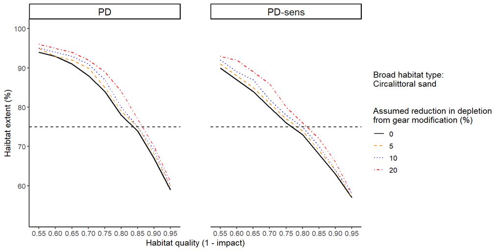

##### Figure 9: Habitat 2

**Figure 9. Effects of gear modifications (5%, 10%, and 20% lower depletion) on the quality-extent relationship for the most abundant MSFD habitat type in the Bay of Biscay and the Iberian Coast area. Habitat quality is defined as 1 - impact, with impact calculated as PD (I‒6a) or PD-sens (I‒7a). The dotted line represent the extent threshold of 75% for the proportion of a broad habitat type that should not be adversely affected (EU, 2024).**

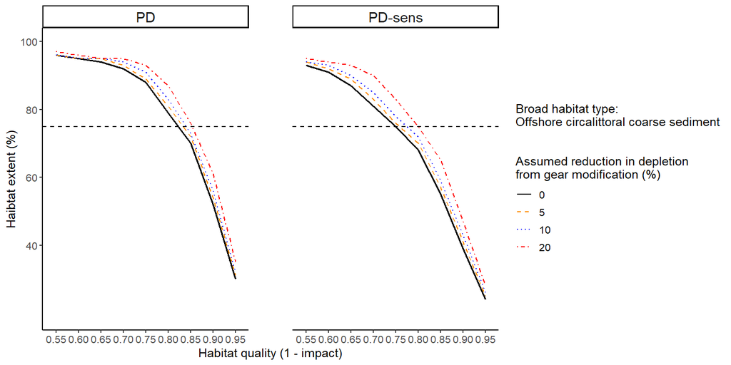

##### Figure 10: Habitat 3

**Figure 10. Effects of gear modifications (5%, 10%, and 20% lower depletion) on the quality-extent relationship for the most abundant MSFD habitat type in the Bay of Biscay and the Iberian Coast area. Habitat quality is defined as 1 - impact, with impact calculated as PD (I‒6a) or PD-sens (I‒7a). The dotted line represent the extent threshold of 75% for the proportion of a broad habitat type that should not be adversely affected (EU, 2024).**

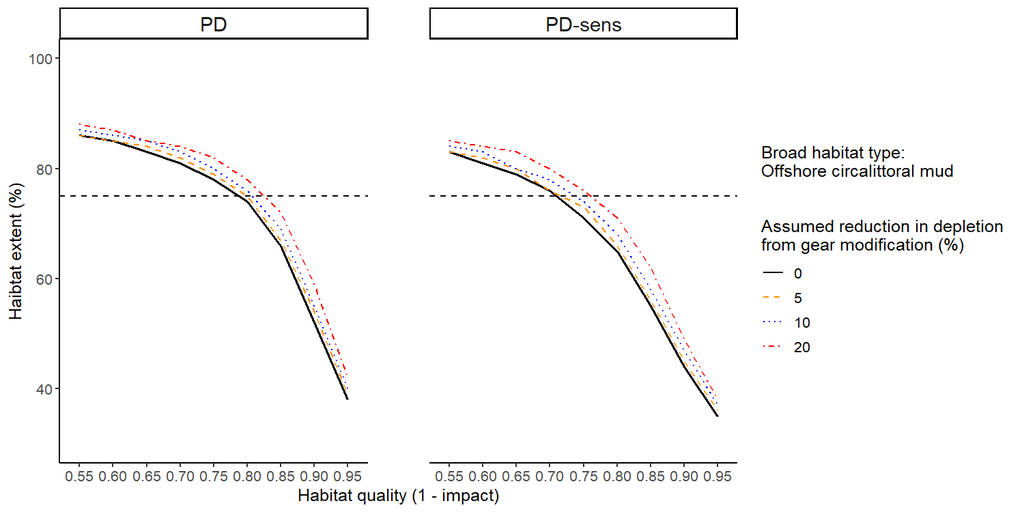

##### Figure 11: Habitat 4

**Figure 11. Effects of gear modifications (5%, 10%, and 20% lower depletion) on the quality-extent relationship for the most abundant MSFD habitat type in the Bay of Biscay and the Iberian Coast area. Habitat quality is defined as 1 - impact, with impact calculated as PD (I‒6a) or PD-sens (I‒7a). The dotted line represent the extent threshold of 75% for the proportion of a broad habitat type that should not be adversely affected (EU, 2024).**

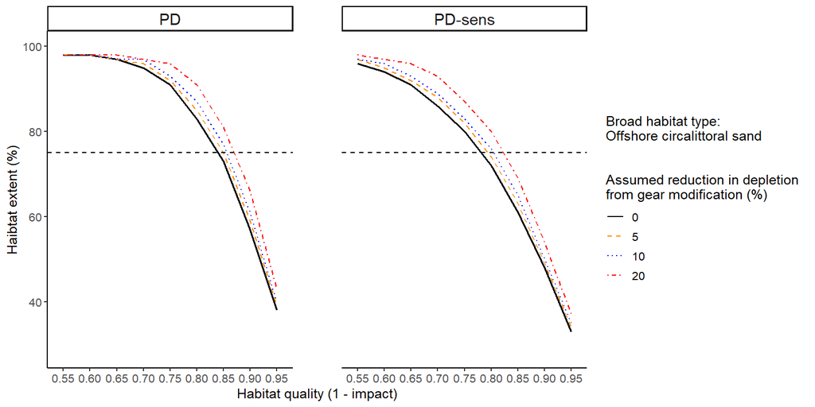

## Gulf of Biscay

### Summary

#### Table 1

**Table 1. Values of pressure and impact indicators for 2017‒2022 for three depth strata in the Gulf of Biscay subdivision. Values of I‒1, I‒2, I‒3, I‒4, I‒6a, I‒6b, I‒7a and I‒7b are annual means and I‒5 is evaluated over the six years. Descriptions of the pressure and impact indicators are provided in the ‘Essential Information’ Table E1 in this document.**

| Indicators | 0 to 200 m | 200 to 400 m | 400 to 800 m |
| --- | --- | --- | --- |
| I‒1: Average fishing intensity | 3.7 | 2.19 | 1.16 |
| I‒2: Proportion of area fished, evaluated at c-square scale (%) | 97.2 | 100.00 | 100.00 |
| I‒3: Proportion of area fished (%) | 85.6 | 90.40 | 71.90 |
| I‒4: Smallest proportion of area with 90% of fishing intensity, evaluated at c-square scale (%) | 60.1 | 68.60 | 61.00 |
| I‒5: Proportion of area persistently unfished, evaluated at c-square scale (%) | 2.8 | 0.00 | 0.00 |
| I‒6a: Average PD impact | 19.2 | 8.80 | 4.40 |
| I‒6b: Average PD-sens impact | 25.4 | 12.40 | 6.10 |
| I‒7a: Proportion of area with PD impact < 0.2, evaluated at c-square scale (%) | 68.8 | 90.60 | 100.00 |
| I‒7b: Proportion of area with PD-sens impact < 0.2, evaluated at c-square scale (%) | 56.4 | 80.80 | 92.70 |

#### Figure 1

**Figure 1. Geographic distribution of fishing intensity (swept area ratio), seabed sensitivity (community longevity), total landings value, and total landings weight from mobile bottom-contacting gear (MBCG) in the Gulf of Biscay subdivision. The maps of swept area ratio, landings value, and landings weight show annual means evaluated at the c-square scale.**

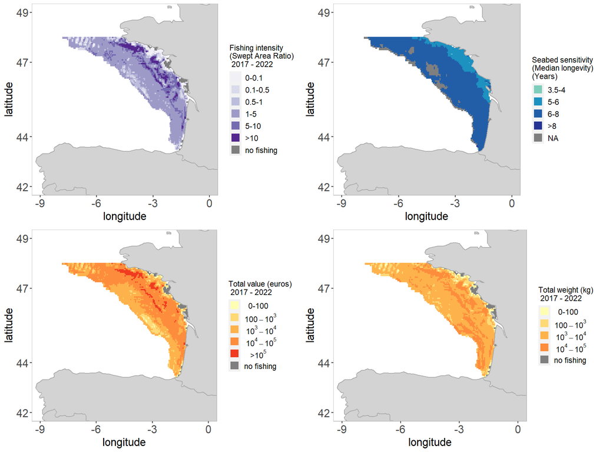

#### Table 2

**Table 2. Contribution of small-scale fisheries (vessels < 12 m overall length) to total fishing effort (kW × fishing days) in the Gulf of Biscay subdivision. The table shows the total fishing effort (kW × fishing days) by FAO region over the assessment period, and the mean contribution (%) and observed range in contribution (%) of small-scale MBCG fisheries’.**

| FAO region code | FAO region name | Total fishing effort (kW × Fishing days) | Mean contribution SSF (%) | Observed range SSF contribution (%) [min - max] |
| --- | --- | --- | --- | --- |
| 27.8.a | Bay of Biscay - North | 10411305 | 23.2 | [21 - 24] |
| 27.8.b | Bay of Biscay - Central | 3154505 | 12.3 | [11 - 14] |
| 27.8.c | Bay of Biscay - South | 4221423 | 2.7 | [0 - 5] |
| 27.8.d | Bay of Biscay - Offshore | 125039 | 1.0 | [0 - 2] |

### Fishing intensity

#### Table 3

**Table 3. Extent (in km<sup>2</sup> and %) of broad habitat types in the Gulf of Biscay subdivision, and mean annual estimates of MBCG fishing intensity, landings weight, and landings value. In addition, estimates of the average annual proportion of the fished extent, the smallest proportion of the habitat extent affected by 90% of the fishing effort, and the proportion of extent persistently unfished are provided.**

| MSFD broad habitat type | Extent of habitat (×1000 km<sup>2</sup>) | Relative habitat extent (%) | Landings (×1000 tonnes) | Value (×10<sup>6</sup> euro) | Swept area (×1000 km<sup>2</sup>) | Average fishing intensity (I‒1) | Average annual extent fished (%) | Smallest proportion of extent with 90% of fishing effort (%) | Percentage extent persistently unfished (%) |
| --- | --- | --- | --- | --- | --- | --- | --- | --- | --- |
| Offshore circalittoral sand | 24.56 | 29.6 | 7.80 | 12.45 | 62.47 | 2.54 | 90.1 | 73.7 | 0.0 |
| Offshore circalittoral mud | 17.10 | 20.6 | 6.93 | 31.08 | 82.30 | 4.81 | 96.8 | 72.8 | 0.1 |
| Offshore circalittoral coarse sediment | 10.55 | 12.7 | 2.74 | 8.00 | 31.49 | 2.98 | 93.8 | 77.3 | 0.0 |
| Circalittoral sand | 9.95 | 12.0 | 2.61 | 13.00 | 35.14 | 3.53 | 84.0 | 65.3 | 1.5 |
| Circalittoral coarse sediment | 7.95 | 9.6 | 4.12 | 19.98 | 51.26 | 6.45 | 88.0 | 64.9 | 0.9 |
| Circalittoral rock and biogenic reef | 2.83 | 3.4 | 0.36 | 1.82 | 3.67 | 1.30 | 48.5 | 44.1 | 5.2 |
| Circalittoral mud | 2.46 | 3.0 | 0.36 | 2.15 | 5.37 | 2.18 | 59.2 | 45.9 | 5.8 |
| Offshore circalittoral rock and biogenic reef | 2.16 | 2.6 | 0.73 | 2.43 | 6.96 | 3.23 | 96.6 | 82.9 | 0.1 |
| Offshore circalittoral mixed sediment | 2.00 | 2.4 | 1.47 | 9.22 | 18.35 | 9.17 | 99.3 | 78.3 | 0.0 |
| Upper bathyal sediment | 1.01 | 1.2 | 0.25 | 0.28 | 1.57 | 1.54 | 73.1 | 66.4 | 0.0 |
| Infralittoral rock and biogenic reef | 0.77 | 0.9 | 0.01 | 0.07 | 0.13 | 0.17 | 9.9 | 20.4 | 39.9 |
| Infralittoral sand | 0.59 | 0.7 | 0.04 | 0.19 | 0.30 | 0.51 | 18.2 | 14.9 | 36.5 |
| Infralittoral coarse sediment | 0.32 | 0.4 | 0.00 | 0.02 | 0.02 | 0.06 | 5.2 | 34.2 | 44.7 |
| Infralittoral mud | 0.31 | 0.4 | 0.01 | 0.04 | 0.07 | 0.22 | 6.8 | 4.0 | 60.1 |
| Circalittoral mixed sediment | 0.21 | 0.3 | 0.06 | 0.33 | 1.05 | 4.94 | 91.8 | 70.8 | 3.3 |
| Unknown | 0.10 | 0.1 | 0.01 | 0.03 | 0.05 | 0.53 | 29.4 | 40.0 | 25.0 |
| Infralittoral mixed sediment | 0.04 | 0.0 | 0.00 | 0.00 | 0.00 | 0.07 | 7.1 | 7.5 | 77.1 |
| Upper bathyal sediment or Upper bathyal rock and biogenic reef | 0.01 | 0.0 | 0.00 | 0.00 | 0.01 | 0.77 | 44.7 | NA | 0.0 |
| Upper bathyal rock and biogenic reef | 0.00 | 0.0 | 0.00 | 0.00 | 0.01 | 4.38 | 100.0 | NA | 0.0 |

#### Figure 2

**Figure 2. Temporal variation of the pressure indicators I‒1, I‒3 and I‒4 in the Gulf of Biscay subdivision. Descriptions of the pressure indicators are provided in the ‘Essential Information’ Table E1 in this document.**

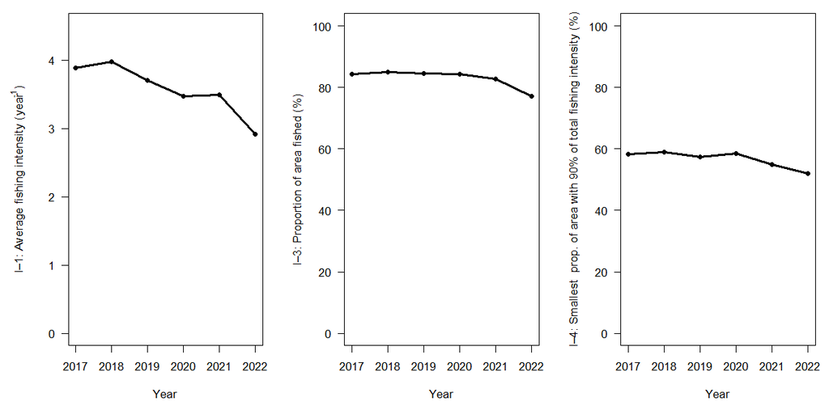

### Fishing by métier

#### Table 4

**Table 4. Landings weight and value by métier and their relationship with swept area in the Gulf of Biscay subdivision.**

|  | OT_DMF | OT_CRU | SDN_DMF | OT_MI | TBB_DMF | OT_SPF |
| --- | --- | --- | --- | --- | --- | --- |
| Area swept (×1000 km<sup>2</sup>) | 140.12 | 65.03 | 49.27 | 42.10 | 2.33 | 1.66 |
| Landings (×1000 tonnes) | 13.82 | 5.11 | 1.75 | 5.68 | 0.49 | 0.63 |
| Value (×10<sup>6</sup> euro) | 34.09 | 35.40 | 8.24 | 18.40 | 4.07 | 0.81 |
| Landings / Area swept (kg/km<sup>2</sup>) | 98.64 | 78.51 | 35.57 | 134.89 | 211.74 | 377.98 |
| Value / Area swept (euro/km<sup>2</sup>) | 243.30 | 544.31 | 167.18 | 437.11 | 1746.13 | 488.75 |

### Core fishing grounds

#### Figure 3

**Figure 3. Spatial stability of core MBCG fishing grounds, presented as the number of years a c-square is identified as a core fishing ground (smallest area yielding 90% of the landings value) per métier for the Gulf of Biscay subdivision. Only métiers that were active within > 50 unique c-squares during the assessment period are included. The numbers between brackets show the proportion of fished extent compared to the overall assessed area extent.**

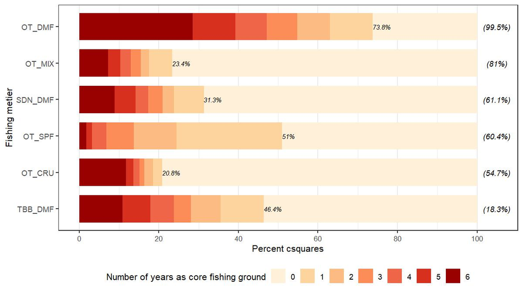

#### Figure 4

**Figure 4. Spatial distribution of the stability of the core MBCG fishing grounds, presented as the number of years a c-square is identified as a core fishing ground (smallest area yielding 90% of the landings value) per métier for the Gulf of Biscay subdivision. Only métiers that were active within > 50 unique c-squares during the assessment period are included.**

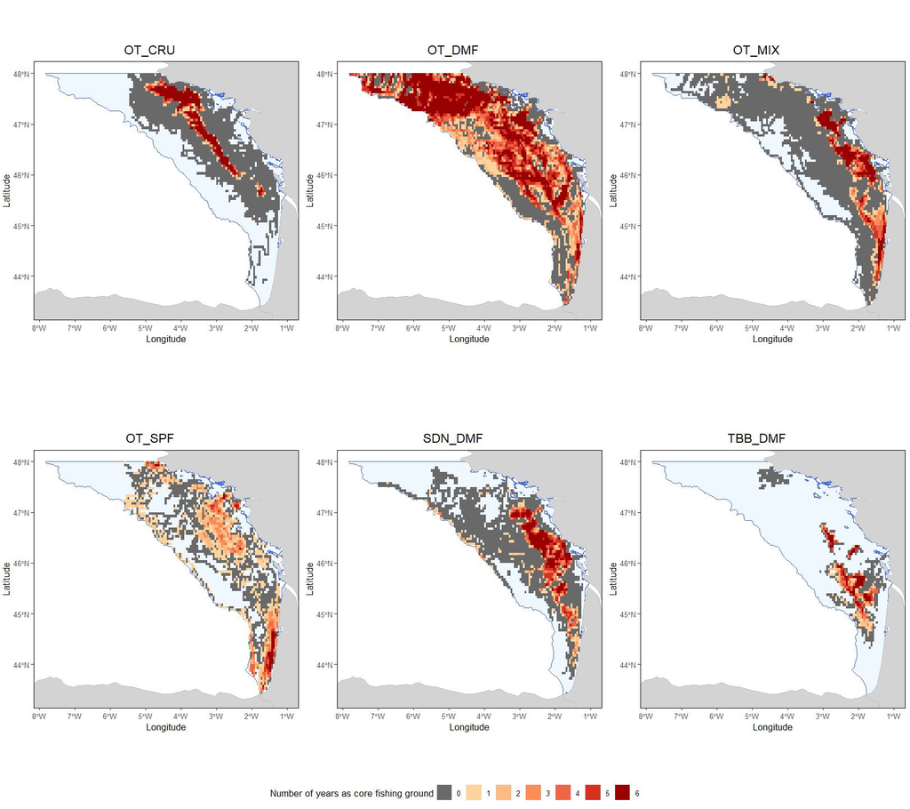

### Impact

#### Figure 5

**Figure 5. The spatial distribution of MBCG fisheries impact in the Gulf of Biscay subdivision, as assessed with the PD indicator (I‒6a) and PD-sens indicator (I‒6b), shown as annual means for the assessment period, evaluated at the c-square scale. Descriptions of the impact indicators are provided in the ‘Essential Information’ Table E1 in this document.**

[figure not shown]

#### Figure 6

**Figure 6. Temporal variation in values of the PD indicator (I‒6a), PD-sens indicator (I‒6b), proportion of the extent with PD impact < 0.2 (I‒7a) and proportion of extent with PD-sens impact < 0.2 (I‒7b), shown for the overall area and for the four most extensive broad habitat types separately in the Gulf of Biscay subdivision. Descriptions of the impact indicators are provided in the ‘Essential Information’ Table E1 in this document.**

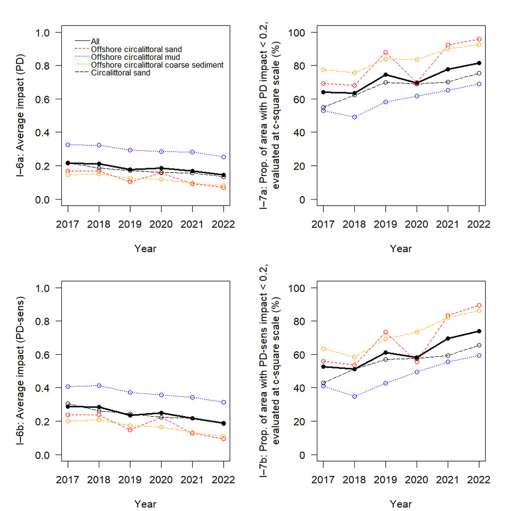

#### Table 5

**Table 5. Métier-specific landings weight and value per unit PD or PD-sens impact in the Gulf of Biscay subdivision.**

|  | OT_DMF | OT_CRU | SDN_DMF | OT_MI | TBB_DMF | OT_SPF |
| --- | --- | --- | --- | --- | --- | --- |
| Landings (tonnes)/PD impact | 59.1 | 17.7 | 65.5 | 30.1 | 24.2 | 100.8 |
| Value (×1000 euro)/PD impact | 145.8 | 123.0 | 307.8 | 97.4 | 199.9 | 130.3 |
| Landings (tonnes)/PD-sens impact | 42.3 | 14.6 | 46.4 | 21.7 | 17.2 | 95.1 |
| Value (×1000 euro)/PD-sens impact | 104.3 | 101.1 | 218.2 | 70.5 | 141.8 | 122.9 |

#### Figure 7

**Figure 7. Métier-related impacts, reported as annual means of the PD indicator (I‒6a, top) and PD-sens indicator (I‒6b, bottom), on the four most extensive broad habitat types in the Gulf of Biscay subdivision.**

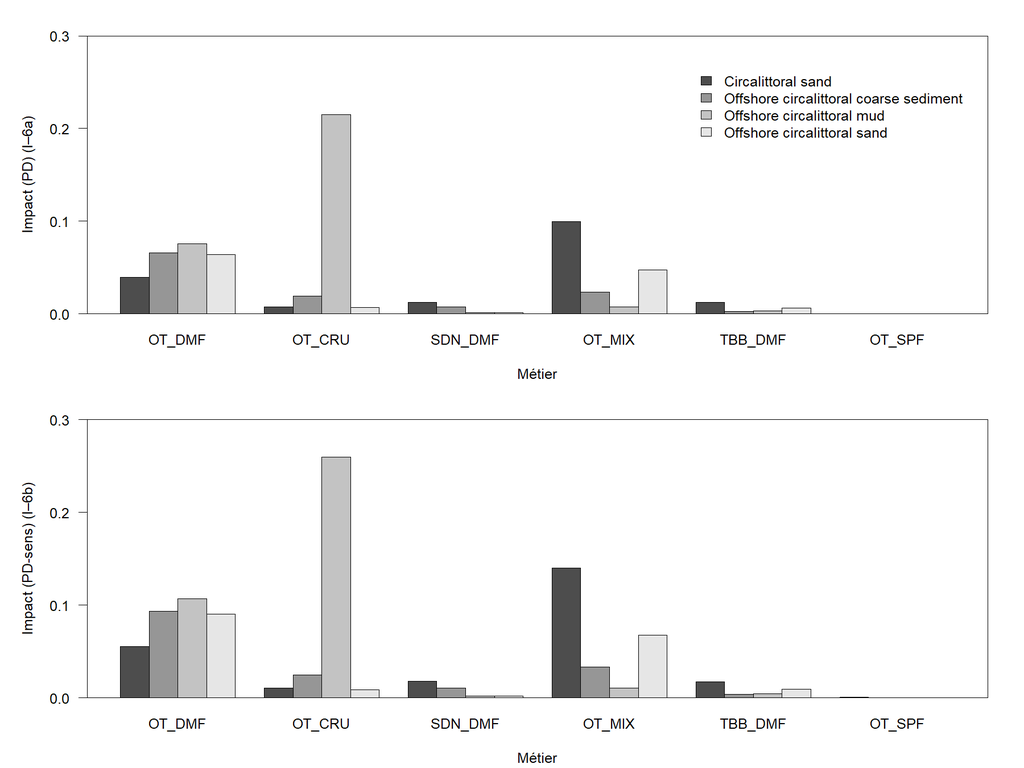

### Scenarios

#### Footprint reduction

##### Table 6: Effort

**Table 6. The effects of stepwise exclusion of all MBCG fisheries from a specified proportion of a MSFD broad habitat type within the Gulf of Biscay subdivision, on swept area (presented as % of total swept area within that habitat type). The stepwise exclusion is conducted in 10% increments, and within each successive increment from 10% to 90% the c-squares with the lowest recorded rank MBCG swept area are excluded. Note that the top row shows the total estimate for all habitats combined.**

| MSFD broad habitat type | Extent of habitat (×1000 km<sup>2</sup>) | Total area swept (×1000 km<sup>2</sup> | 10% | 20% | 30% | 40% | 50% | 60% | 70% | 80% | 90% |
| --- | --- | --- | --- | --- | --- | --- | --- | --- | --- | --- | --- |
| total | 82.91 | 100 | 2.0 | 5.7 | 10.7 | 17.4 | 25.0 | 33.8 | 43.9 | 56.3 | 72.5 |
| Offshore circalittoral sand | 24.56 | 62.47 | 2.0 | 6.5 | 12.5 | 20.2 | 29.0 | 38.8 | 50.4 | 63.3 | 78.8 |
| Offshore circalittoral mud | 17.1 | 82.3 | 2.5 | 6.5 | 11.5 | 17.5 | 24.3 | 31.8 | 40.5 | 51.4 | 67.3 |
| Offshore circalittoral coarse sediment | 10.55 | 31.49 | 4.1 | 8.7 | 14.2 | 20.9 | 28.9 | 37.6 | 47.3 | 58.9 | 73.2 |
| Circalittoral sand | 9.95 | 35.14 | 0.2 | 2.4 | 7.1 | 13.4 | 20.4 | 29.8 | 40.2 | 53.7 | 71.7 |
| Circalittoral coarse sediment | 7.95 | 51.26 | 0.3 | 2.4 | 6.6 | 13.6 | 21.8 | 30.9 | 41.2 | 53.8 | 70.7 |
| Circalittoral rock and biogenic reef | 2.83 | 3.67 | <0.1 | 0.7 | 1.9 | 4.4 | 6.9 | 12.3 | 20.7 | 36.1 | 55.9 |
| Circalittoral mud | 2.46 | 5.37 | <0.1 | 0.3 | 1.3 | 3.5 | 7.9 | 14.0 | 24.3 | 39.4 | 59.0 |
| Offshore circalittoral rock and biogenic reef | 2.16 | 6.96 | 6.1 | 12.6 | 19.5 | 27.4 | 35.5 | 46.5 | 55.4 | 69.1 | 82.7 |
| Offshore circalittoral mixed sediment | 2 | 18.35 | 3.9 | 9.0 | 15.3 | 22.6 | 30.3 | 40.8 | 53.0 | 67.0 | 83.2 |
| Upper bathyal sediment | 1.01 | 1.57 | 1.6 | 5.8 | 8.8 | 14.0 | 22.3 | 34.7 | 46.9 | 58.1 | 74.8 |
| Infralittoral rock and biogenic reef | 0.77 | 0.13 | 0.0 | 0.0 | 0.0 | <0.1 | 0.3 | 1.9 | 4.0 | 11.1 | 24.7 |
| Infralittoral sand | 0.59 | 0.3 | 0.0 | 0.0 | 0.0 | <0.1 | 0.2 | 0.6 | 2.1 | 5.4 | 23.8 |
| Infralittoral coarse sediment | 0.32 | 0.02 | 0.0 | 0.0 | 0.0 | 0.0 | 1.0 | 5.4 | 16.3 | 27.6 | 57.5 |
| Infralittoral mud | 0.31 | 0.07 | 0.0 | 0.0 | 0.0 | 0.0 | 0.0 | <0.1 | 1.0 | 1.7 | 3.6 |
| Circalittoral mixed sediment | 0.21 | 1.05 | 1.1 | 5.5 | 11.7 | 20.2 | 29.7 | 38.4 | 48.9 | 66.0 | 90.0 |
| Unknown | 0.1 | 0.05 | <0.1 | 1.1 | 4.1 | 15.7 | 22.0 | 29.3 | 37.8 | 47.6 | 77.6 |
| Infralittoral mixed sediment | 0.04 | 0 | 0.0 | 0.0 | 0.0 | 0.0 | 0.0 | 0.0 | 0.0 | 0.3 | 24.0 |
| Upper bathyal rock and biogenic reef | 0 | 0.01 | 100.0 | 100.0 | 100.0 | 100.0 | 100.0 | 100.0 | 100.0 | 100.0 | 100.0 |

##### Table 7: Landings weight

**Table 7. The effects of stepwise exclusion of all MBCG fisheries from a specified proportion of a MSFD broad habitat type within the Gulf of Biscay subdivision, on landings weight (presented as % of total landings weight within that habitat type). The stepwise exclusion is conducted in 10% increments, and within each successive increment from 10% to 90% the c-squares with the lowest recorded rank MBCG swept area are excluded. Note that the top row shows the total estimate for all habitats combined.**

| MSFD broad habitat type | Extent of habitat (×1000 km<sup>2</sup>) | Total landings weight (×1000 kg) | 10% | 20% | 30% | 40% | 50% | 60% | 70% | 80% | 90% |
| --- | --- | --- | --- | --- | --- | --- | --- | --- | --- | --- | --- |
| Total | 82.91 | 27387.1 | 2.4 | 6.6 | 12.0 | 19.2 | 26.9 | 36.5 | 47.1 | 60.2 | 75.8 |
| Offshore circalittoral sand | 24.56 | 7755.1 | 1.8 | 6.2 | 11.5 | 19.7 | 28.1 | 39.4 | 52.2 | 67.0 | 82.8 |
| Offshore circalittoral mud | 17.1 | 6919 | 3.4 | 8.5 | 14.7 | 21.9 | 29.4 | 37.8 | 46.8 | 58.4 | 73.7 |
| Offshore circalittoral coarse sediment | 10.55 | 2735.8 | 4.9 | 10.7 | 17.1 | 24.6 | 32.9 | 43.7 | 54.6 | 66.8 | 81.1 |
| Circalittoral sand | 9.95 | 2605.5 | 0.5 | 3.1 | 8.3 | 14.8 | 22.5 | 31.8 | 42.1 | 55.0 | 73.4 |
| Circalittoral coarse sediment | 7.95 | 4115.7 | 0.4 | 3.0 | 7.0 | 13.3 | 20.6 | 28.3 | 36.5 | 48.6 | 63.6 |
| Circalittoral rock and biogenic reef | 2.83 | 356.6 | 0.2 | 1.0 | 2.2 | 5.0 | 7.8 | 12.5 | 23.3 | 39.7 | 60.4 |
| Circalittoral mud | 2.46 | 358.4 | <0.1 | 0.7 | 2.3 | 5.8 | 11.4 | 19.6 | 30.5 | 45.8 | 65.5 |
| Offshore circalittoral rock and biogenic reef | 2.16 | 725.6 | 5.9 | 11.1 | 18.3 | 25.9 | 32.1 | 42.0 | 52.6 | 67.1 | 80.0 |
| Offshore circalittoral mixed sediment | 2 | 1475 | 4.0 | 9.4 | 15.5 | 22.8 | 30.8 | 41.4 | 53.8 | 68.3 | 83.7 |
| Upper bathyal sediment | 1.01 | 219.2 | 1.6 | 5.1 | 7.7 | 13.9 | 21.3 | 31.7 | 52.1 | 60.1 | 72.5 |
| Infralittoral rock and biogenic reef | 0.77 | 12.6 | 0.0 | 0.0 | 0.0 | <0.1 | 1.4 | 8.5 | 11.3 | 24.1 | 37.7 |
| Infralittoral sand | 0.59 | 35.3 | 0.0 | 0.0 | 0.0 | <0.1 | 0.2 | 2.3 | 3.8 | 9.4 | 24.1 |
| Infralittoral coarse sediment | 0.32 | 4.2 | 0.0 | 0.0 | 0.0 | 0.0 | 1.1 | 11.5 | 24.6 | 31.2 | 50.1 |
| Infralittoral mud | 0.31 | 6.3 | 0.0 | 0.0 | 0.0 | 0.0 | 0.0 | 0.2 | 5.8 | 9.0 | 11.0 |
| Circalittoral mixed sediment | 0.21 | 56.4 | 1.4 | 6.5 | 13.9 | 22.8 | 32.6 | 40.8 | 51.1 | 66.4 | 91.9 |
| Unknown | 0.1 | 4.7 | <0.1 | 0.8 | 2.1 | 15.4 | 20.0 | 25.8 | 29.2 | 37.7 | 74.7 |
| Infralittoral mixed sediment | 0.04 | 0.3 | 0.0 | 0.0 | 0.0 | 0.0 | 0.0 | 0.0 | 0.0 | 0.2 | 29.2 |
| Upper bathyal rock and biogenic reef | 0 | 1.3 | 100.0 | 100.0 | 100.0 | 100.0 | 100.0 | 100.0 | 100.0 | 100.0 | 100.0 |

##### Table 8: Landings value

**Table 8. The effects of stepwise exclusion of all MBCG fisheries from a specified proportion of a MSFD broad habitat type within the Gulf of Biscay subdivision, on landings value (presented as % of total landings value within that habitat type). The stepwise exclusion is conducted in 10% increments, and within each successive increment from 10% to 90% the c-squares with the lowest recorded rank MBCG swept area are excluded. Note that the top row shows the total estimate for all habitats combined.**

| MSFD broad habitat type | Extent of habitat (×1000 km<sup>2</sup>) | Total landings value (×1000 euro) | 10% | 20% | 30% | 40% | 50% | 60% | 70% | 80% | 90% |
| --- | --- | --- | --- | --- | --- | --- | --- | --- | --- | --- | --- |
| Total | 82.91 | 101044.8 | 1.7 | 5.0 | 9.4 | 15.5 | 22.3 | 30.2 | 39.1 | 50.7 | 67.6 |
| Offshore circalittoral sand | 24.56 | 12445.6 | 2.7 | 7.6 | 13.6 | 21.1 | 29.9 | 38.8 | 49.1 | 59.6 | 74.4 |
| Offshore circalittoral mud | 17.1 | 31070.1 | 1.6 | 4.3 | 7.8 | 12.4 | 17.2 | 23.0 | 29.8 | 39.8 | 59.3 |
| Offshore circalittoral coarse sediment | 10.55 | 7995.3 | 4.3 | 8.8 | 14.6 | 21.2 | 29.3 | 37.4 | 47.0 | 57.8 | 72.4 |
| Circalittoral sand | 9.95 | 12998.2 | 0.4 | 2.9 | 8.1 | 14.6 | 22.5 | 32.2 | 42.1 | 54.4 | 72.2 |
| Circalittoral coarse sediment | 7.95 | 19976.2 | 0.4 | 3.0 | 7.0 | 13.7 | 21.0 | 28.8 | 37.2 | 49.0 | 63.5 |
| Circalittoral rock and biogenic reef | 2.83 | 1823.7 | 0.2 | 0.9 | 2.0 | 4.5 | 7.0 | 12.0 | 21.9 | 39.4 | 59.8 |
| Circalittoral mud | 2.46 | 2146.1 | <0.1 | 0.4 | 1.7 | 4.4 | 8.9 | 15.8 | 26.5 | 41.7 | 61.4 |
| Offshore circalittoral rock and biogenic reef | 2.16 | 2425.1 | 6.4 | 13.5 | 21.4 | 29.5 | 39.5 | 52.6 | 59.5 | 73.9 | 86.3 |
| Offshore circalittoral mixed sediment | 2 | 9216.3 | 3.0 | 6.8 | 12.5 | 19.9 | 27.7 | 38.2 | 51.4 | 66.8 | 83.0 |
| Upper bathyal sediment | 1.01 | 279 | 2.7 | 7.9 | 12.2 | 17.3 | 24.6 | 36.1 | 46.0 | 55.9 | 77.4 |
| Infralittoral rock and biogenic reef | 0.77 | 71.6 | 0.0 | 0.0 | 0.0 | <0.1 | 1.0 | 6.1 | 8.1 | 18.4 | 31.0 |
| Infralittoral sand | 0.59 | 187.9 | 0.0 | 0.0 | 0.0 | <0.1 | 0.3 | 1.8 | 3.4 | 8.6 | 23.5 |
| Infralittoral coarse sediment | 0.32 | 21 | 0.0 | 0.0 | 0.0 | 0.0 | 1.1 | 9.1 | 21.1 | 27.0 | 47.7 |
| Infralittoral mud | 0.31 | 36.8 | 0.0 | 0.0 | 0.0 | 0.0 | 0.0 | 0.2 | 4.4 | 7.1 | 8.9 |
| Circalittoral mixed sediment | 0.21 | 326.7 | 1.4 | 6.1 | 11.9 | 21.1 | 31.1 | 39.8 | 49.1 | 64.3 | 91.5 |
| Unknown | 0.1 | 23.2 | <0.1 | 1.0 | 2.5 | 15.1 | 20.1 | 25.6 | 29.7 | 39.6 | 75.4 |
| Infralittoral mixed sediment | 0.04 | 1.9 | 0.0 | 0.0 | 0.0 | 0.0 | 0.0 | 0.0 | 0.0 | 0.2 | 22.6 |
| Upper bathyal rock and biogenic reef | 0 | 0.1 | 100.0 | 100.0 | 100.0 | 100.0 | 100.0 | 100.0 | 100.0 | 100.0 | 100.0 |

#### Gear modifications

##### Figure 8: Habitat 1

**Figure 8. Effects of gear modifications (5%, 10%, and 20% lower depletion) on the quality-extent relationship for the most abundant MSFD habitat type in the Gulf of Biscay subdivision. Habitat quality is defined as 1 - impact, with impact calculated as PD (I‒6a) or PD-sens (I‒7a). The dotted line represent the extent threshold of 75% for the proportion of a broad habitat type that should not be adversely affected (EU, 2024).**

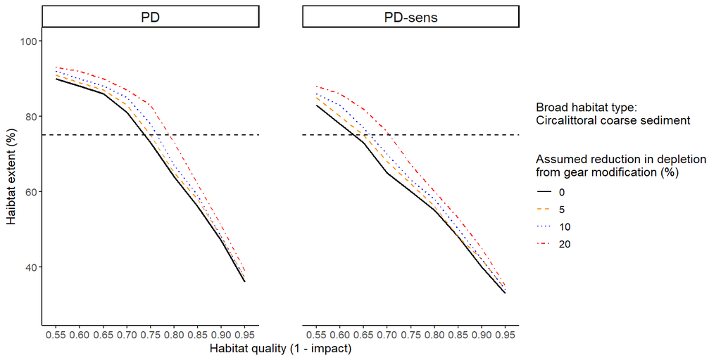

##### Figure 9: Habitat 2

**Figure 9. Effects of gear modifications (5%, 10%, and 20% lower depletion) on the quality-extent relationship for the most abundant MSFD habitat type in the Gulf of Biscay subdivision. Habitat quality is defined as 1 - impact, with impact calculated as PD (I‒6a) or PD-sens (I‒7a). The dotted line represent the extent threshold of 75% for the proportion of a broad habitat type that should not be adversely affected (EU, 2024).**

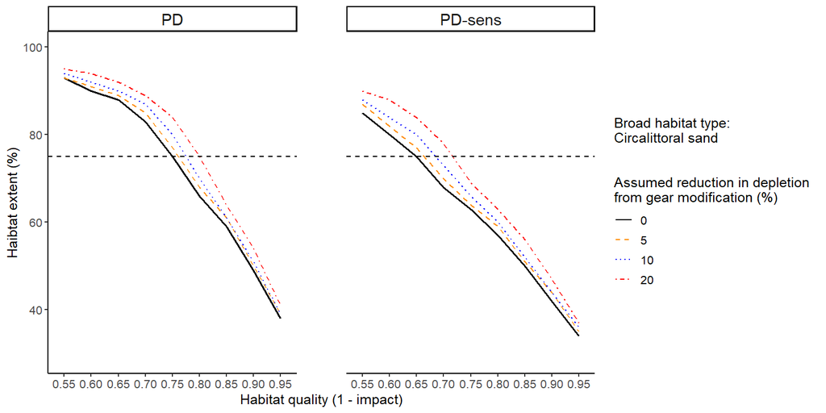

##### Figure 10: Habitat 3

**Figure 10. Effects of gear modifications (5%, 10%, and 20% lower depletion) on the quality-extent relationship for the most abundant MSFD habitat type in the Gulf of Biscay subdivision. Habitat quality is defined as 1 - impact, with impact calculated as PD (I‒6a) or PD-sens (I‒7a). The dotted line represent the extent threshold of 75% for the proportion of a broad habitat type that should not be adversely affected (EU, 2024).**

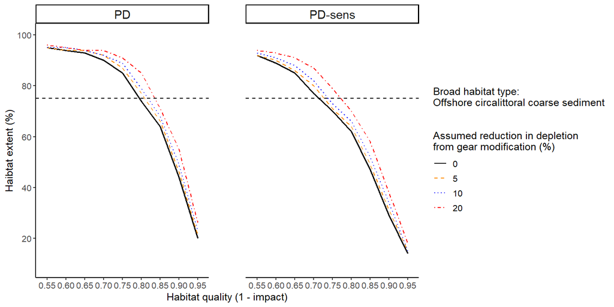

##### Figure 11: Habitat 4

**Figure 11. Effects of gear modifications (5%, 10%, and 20% lower depletion) on the quality-extent relationship for the most abundant MSFD habitat type in the Gulf of Biscay subdivision. Habitat quality is defined as 1 - impact, with impact calculated as PD (I‒6a) or PD-sens (I‒7a). The dotted line represent the extent threshold of 75% for the proportion of a broad habitat type that should not be adversely affected (EU, 2024).**

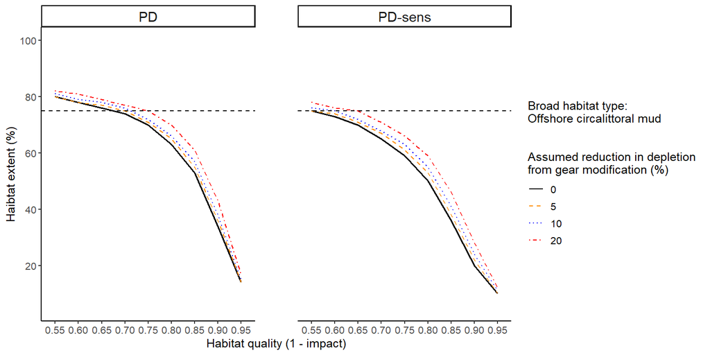

## North-Iberian Atlantic

### Summary

#### Table 1

**Table 1. Values of pressure and impact indicators for 2017‒2022 for three depth strata in the North-Iberian Atlantic subdivision. Values of I‒1, I‒2, I‒3, I‒4, I‒6a, I‒6b, I‒7a and I‒7b are annual means and I‒5 is evaluated over the six years. Descriptions of the pressure and impact indicators are provided in the ‘Essential Information’ Table E1 in this document.**

| Indicators | 0 to 200 m | 200 to 400 m | 400 to 800 m |
| --- | --- | --- | --- |
| I‒1: Average fishing intensity | 1.91 | 3.96 | 0.76 |
| I‒2: Proportion of area fished, evaluated at c-square scale (%) | 77.50 | 97.70 | 76.20 |
| I‒3: Proportion of area fished (%) | 61.00 | 83.60 | 30.80 |
| I‒4: Smallest proportion of area with 90% of fishing intensity, evaluated at c-square scale (%) | 44.30 | 55.40 | 24.40 |
| I‒5: Proportion of area persistently unfished, evaluated at c-square scale (%) | 22.50 | 2.30 | 23.80 |
| I‒6a: Average PD impact | 7.60 | 19.20 | 3.90 |
| I‒6b: Average PD-sens impact | 9.50 | 24.00 | 5.10 |
| I‒7a: Proportion of area with PD impact < 0.2, evaluated at c-square scale (%) | 90.30 | 59.80 | 93.90 |
| I‒7b: Proportion of area with PD-sens impact < 0.2, evaluated at c-square scale (%) | 84.10 | 53.70 | 91.70 |

#### Figure 1

**Figure 1. Geographic distribution of fishing intensity (swept area ratio), seabed sensitivity (community longevity), total landings value, and total landings weight from mobile bottom-contacting gear (MBCG) in the North-Iberian Atlantic subdivision. The maps of swept area ratio, landings value, and landings weight show annual means evaluated at the c-square scale.**

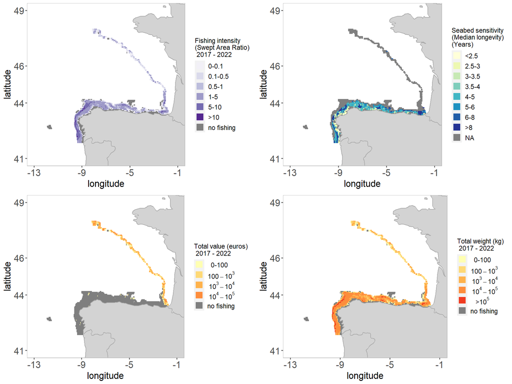

#### Table 2

**Table 2. Contribution of small-scale fisheries (vessels < 12 m overall length) to total fishing effort (kW × fishing days) in the North-Iberian Atlantic subdivision. The table shows the total fishing effort (kW × fishing days) by FAO region over the assessment period, and the mean contribution (%) and observed range in contribution (%) of small-scale MBCG fisheries’.**

| FAO region code | FAO region name | Total fishing effort (kW × Fishing days) | Mean contribution SSF (%) | Observed range SSF contribution (%) [min - max] |
| --- | --- | --- | --- | --- |
| 27.8.a | Bay of Biscay - North | 10411305 | 23.2 | [21 - 24] |
| 27.8.b | Bay of Biscay - Central | 3154505 | 12.3 | [11 - 14] |
| 27.8.c | Bay of Biscay - South | 4221423 | 2.7 | [0 - 5] |
| 27.8.d | Bay of Biscay - Offshore | 125039 | 1.0 | [0 - 2] |
| 27.9.a | Portuguese Waters - East | 7567817 | 23.2 | [2 - 34] |

### Fishing intensity

#### Table 3

**Table 3. Extent (in km<sup>2</sup> and %) of broad habitat types in the North-Iberian Atlantic subdivision, and mean annual estimates of MBCG fishing intensity, landings weight, and landings value. In addition, estimates of the average annual proportion of the fished extent, the smallest proportion of the habitat extent affected by 90% of the fishing effort, and the proportion of extent persistently unfished are provided.**

| MSFD broad habitat type | Extent of habitat (×1000 km<sup>2</sup>) | Relative habitat extent (%) | Landings (×1000 tonnes) | Value (×10<sup>6</sup> euro) | Swept area (×1000 km<sup>2</sup>) | Average fishing intensity (I‒1) | Average annual extent fished (%) | Smallest proportion of extent with 90% of fishing effort (%) | Percentage extent persistently unfished (%) |
| --- | --- | --- | --- | --- | --- | --- | --- | --- | --- |
| Upper bathyal sediment | 15.27 | 37.3 | 19.82 | NA | 34.99 | 2.29 | 57.4 | 39.2 | 10.4 |
| Offshore circalittoral sand | 7.58 | 18.5 | 7.58 | NA | 20.18 | 2.66 | 81.8 | 64.2 | 3.3 |
| Offshore circalittoral mud | 4.39 | 10.7 | 6.15 | NA | 15.31 | 3.49 | 93.6 | 78.1 | 1.1 |
| Offshore circalittoral rock and biogenic reef | 2.89 | 7.1 | 1.63 | NA | 3.41 | 1.18 | 57.7 | 54.5 | 14.9 |
| Circalittoral rock and biogenic reef | 2.28 | 5.6 | 0.29 | NA | 0.47 | 0.21 | 12.1 | 15.3 | 64.8 |
| Circalittoral sand | 1.55 | 3.8 | 0.34 | NA | 0.50 | 0.33 | 15.7 | 15.4 | 64.8 |
| Upper bathyal sediment or Upper bathyal rock and biogenic reef | 1.46 | 3.6 | 0.15 | NA | 0.25 | 0.17 | 13.5 | 19.9 | 42.8 |
| Offshore circalittoral coarse sediment | 1.24 | 3.0 | 0.91 | NA | 1.75 | 1.40 | 70.0 | 64.4 | 7.3 |
| Upper bathyal rock and biogenic reef | 0.86 | 2.1 | 0.88 | NA | 1.43 | 1.66 | 50.3 | 42.0 | 28.9 |
| Offshore circalittoral mixed sediment | 0.66 | 1.6 | 0.74 | NA | 2.12 | 3.21 | 92.1 | 75.9 | 4.3 |
| Infralittoral rock and biogenic reef | 0.53 | 1.3 | 0.01 | NA | 0.02 | 0.03 | 2.8 | 6.1 | 84.9 |
| Lower bathyal sediment | 0.50 | 1.2 | 0.03 | NA | 0.05 | 0.10 | 7.4 | 26.7 | 28.2 |
| Circalittoral coarse sediment | 0.49 | 1.2 | 0.10 | NA | 0.15 | 0.31 | 16.6 | 22.3 | 50.8 |
| Circalittoral mud | 0.31 | 0.8 | 0.02 | NA | 0.04 | 0.15 | 8.6 | 11.4 | 68.6 |
| Infralittoral sand | 0.27 | 0.7 | 0.00 | NA | 0.00 | 0.02 | 1.6 | 7.5 | 88.1 |
| Lower bathyal sediment or Lower bathyal rock and biogenic reef | 0.24 | 0.6 | 0.01 | NA | 0.01 | 0.04 | 4.1 | 43.4 | 48.0 |
| Circalittoral mixed sediment | 0.12 | 0.3 | 0.01 | NA | 0.01 | 0.09 | 4.7 | 9.3 | 69.0 |
| Infralittoral mud | 0.08 | 0.2 | 0.00 | NA | 0.00 | 0.00 | 0.2 | 3.8 | 94.2 |
| Infralittoral mixed sediment | 0.07 | 0.2 | 0.00 | NA | 0.00 | 0.00 | 0.2 | 4.7 | 88.8 |
| Unknown | 0.06 | 0.1 | 0.12 | NA | 0.08 | 1.49 | 83.9 | 49.2 | 13.1 |
| Lower bathyal rock and biogenic reef | 0.04 | 0.1 | 0.00 | NA | 0.00 | 0.04 | 3.7 | 64.9 | 30.5 |
| Infralittoral coarse sediment | 0.03 | 0.1 | 0.00 | NA | 0.01 | 0.19 | 7.8 | 5.3 | 78.4 |
| Abyssal | 0.01 | 0.0 | 0.00 | NA | 0.00 | 0.01 | 1.4 | NA | 0.0 |

#### Figure 2

**Figure 2. Temporal variation of the pressure indicators I‒1, I‒3 and I‒4 in the North-Iberian Atlantic subdivision. Descriptions of the pressure indicators are provided in the ‘Essential Information’ Table E1 in this document.**

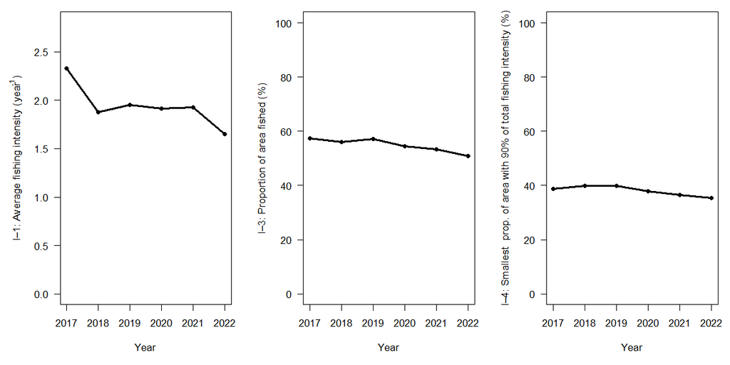

### Fishing by métier

#### Table 4

**Table 4. Landings weight and value by métier and their relationship with swept area in the North-Iberian Atlantic subdivision.**

|  | OT_DMF | OT_MI | SDN_DMF | OT_SPF |
| --- | --- | --- | --- | --- |
| Area swept (×1000 km<sup>2</sup>) | 54.35 | 25.87 | 0.41 | 0.10 |
| Landings (×1000 tonnes) | 8.92 | 29.45 | 0.04 | 0.37 |
| Value (×10<sup>6</sup> euro) | NA | NA | NA | NA |
| Landings / Area swept (kg/km<sup>2</sup>) | 164.12 | 1138.55 | 89.00 | 3718.83 |
| Value / Area swept (euro/km<sup>2</sup>) | NA | NA | NA | NA |

### Core fishing grounds

**Core fishing grounds could not be identified in this subdivision.**

### Impact

#### Figure 5

**Figure 5. The spatial distribution of MBCG fisheries impact in the North-Iberian Atlantic subdivision, as assessed with the PD indicator (I‒6a) and PD-sens indicator (I‒6b), shown as annual means for the assessment period, evaluated at the c-square scale. Descriptions of the impact indicators are provided in the ‘Essential Information’ Table E1 in this document.**

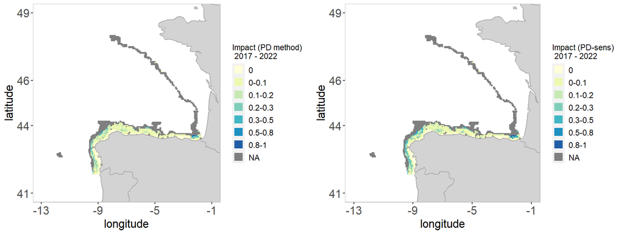

#### Figure 6

**Figure 6. Temporal variation in values of the PD indicator (I‒6a), PD-sens indicator (I‒6b), proportion of the extent with PD impact < 0.2 (I‒7a) and proportion of extent with PD-sens impact < 0.2 (I‒7b), shown for the overall area and for the four most extensive broad habitat types separately in the North-Iberian Atlantic subdivision. Descriptions of the impact indicators are provided in the ‘Essential Information’ Table E1 in this document.**

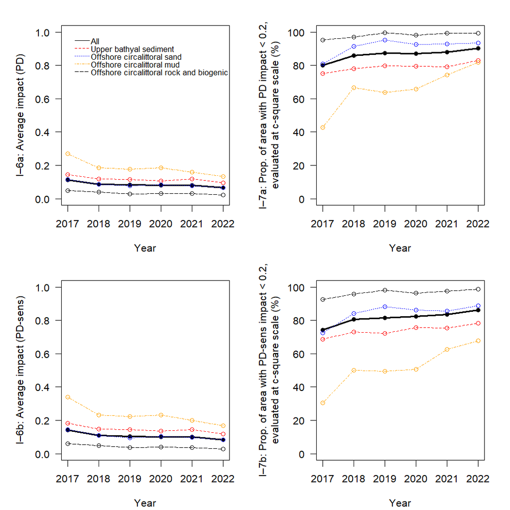

#### Table 5

**Table 5. Métier-specific landings weight and value per unit PD or PD-sens impact in the North-Iberian Atlantic subdivision.**

|  | OT_DMF | OT_MI | SDN_DMF | OT_SPF |
| --- | --- | --- | --- | --- |
| Landings (tonnes)/PD impact | 81.4 | 238.4 | 41.0 | 65.9 |
| Value (×1000 euro)/PD impact | NA | NA | NA | NA |
| Landings (tonnes)/PD-sens impact | 70.3 | 200.2 | 37.2 | 65.8 |
| Value (×1000 euro)/PD-sens impact | NA | NA | NA | NA |

#### Figure 7

**Figure 7. Métier-related impacts, reported as annual means of the PD indicator (I‒6a, top) and PD-sens indicator (I‒6b, bottom), on the four most extensive broad habitat types in the North-Iberian Atlantic subdivision.**

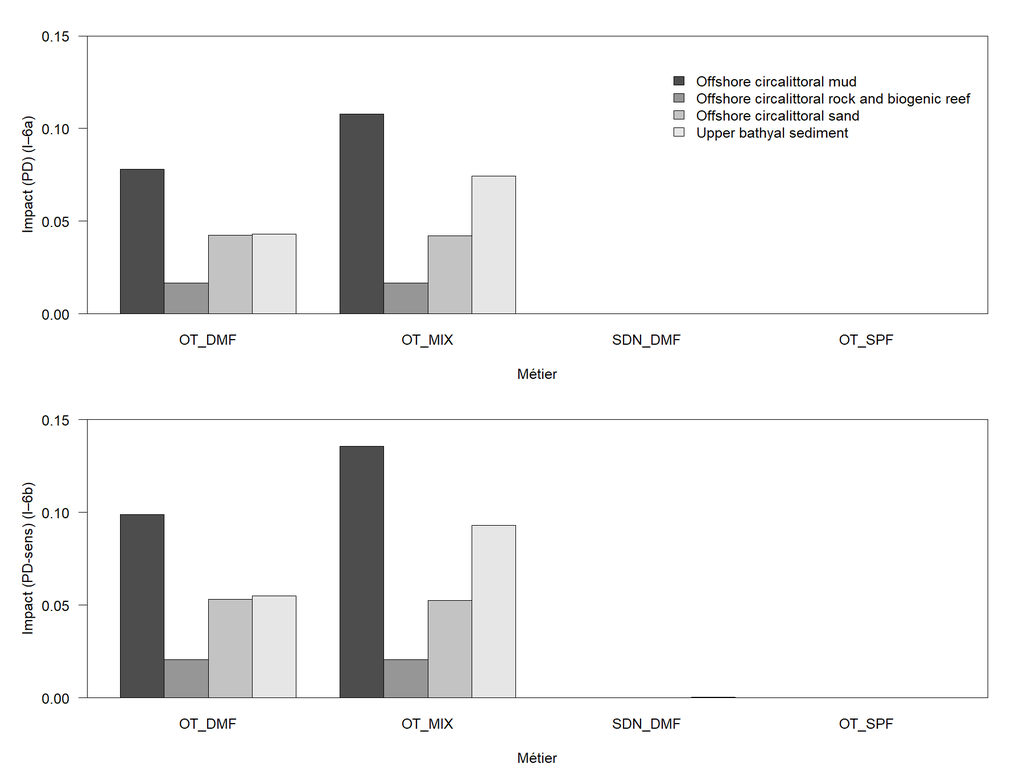

### Scenarios

#### Footprint reduction

##### Table 6: Effort

**Table 6. The effects of stepwise exclusion of all MBCG fisheries from a specified proportion of a MSFD broad habitat type within the North-Iberian Atlantic subdivision, on swept area (presented as % of total swept area within that habitat type). The stepwise exclusion is conducted in 10% increments, and within each successive increment from 10% to 90% the c-squares with the lowest recorded rank MBCG swept area are excluded. Note that the top row shows the total estimate for all habitats combined.**

| MSFD broad habitat type | Extent of habitat (×1000 km<sup>2</sup>) | Total area swept (×1000 km<sup>2</sup> | 10% | 20% | 30% | 40% | 50% | 60% | 70% | 80% | 90% |
| --- | --- | --- | --- | --- | --- | --- | --- | --- | --- | --- | --- |
| total | 40.93 | 100 | 0.5 | 2.6 | 5.7 | 10.3 | 15.9 | 23.6 | 34.3 | 49.5 | 69.6 |
| Upper bathyal sediment | 15.27 | 34.99 | 0.0 | <0.1 | 0.5 | 1.7 | 4.3 | 9.4 | 19.2 | 36.8 | 60.5 |
| Offshore circalittoral sand | 7.58 | 20.18 | 0.3 | 2.2 | 6.7 | 13.1 | 20.6 | 30.7 | 43.6 | 57.9 | 76.6 |
| Offshore circalittoral mud | 4.39 | 15.31 | 2.0 | 8.9 | 17.0 | 26.7 | 36.2 | 45.1 | 55.4 | 67.4 | 82.3 |
| Offshore circalittoral rock and biogenic reef | 2.89 | 3.41 | 0.0 | 0.2 | 2.1 | 6.8 | 13.8 | 22.3 | 35.6 | 51.3 | 73.6 |
| Circalittoral rock and biogenic reef | 2.28 | 0.47 | 0.0 | 0.0 | 0.0 | 0.0 | 0.0 | 0.0 | 0.4 | 4.3 | 22.2 |
| Circalittoral sand | 1.55 | 0.5 | 0.0 | 0.0 | 0.0 | 0.0 | 0.0 | 0.0 | 0.5 | 5.2 | 23.4 |
| Upper bathyal sediment or Upper bathyal rock and biogenic reef | 1.46 | 0.25 | 0.0 | 0.0 | 0.0 | 0.0 | 0.2 | 1.5 | 4.4 | 10.1 | 32.8 |
| Offshore circalittoral coarse sediment | 1.24 | 1.75 | 0.1 | 1.7 | 6.5 | 13.9 | 22.2 | 33.5 | 43.4 | 58.1 | 74.6 |
| Upper bathyal rock and biogenic reef | 0.86 | 1.43 | 0.0 | 0.0 | <0.1 | 0.5 | 2.9 | 12.0 | 29.5 | 47.6 | 68.1 |
| Offshore circalittoral mixed sediment | 0.66 | 2.12 | 2.5 | 7.8 | 15.1 | 24.5 | 34.1 | 48.7 | 58.7 | 67.9 | 81.1 |
| Infralittoral rock and biogenic reef | 0.53 | 0.02 | 0.0 | 0.0 | 0.0 | 0.0 | 0.0 | 0.0 | 0.0 | 0.0 | 1.8 |
| Lower bathyal sediment | 0.5 | 0.05 | 0.0 | 0.0 | <0.1 | 1.5 | 1.9 | 3.6 | 9.6 | 17.6 | 40.3 |
| Circalittoral coarse sediment | 0.49 | 0.15 | 0.0 | 0.0 | 0.0 | 0.0 | 0.0 | 0.7 | 3.5 | 11.1 | 29.8 |
| Circalittoral mud | 0.31 | 0.04 | 0.0 | 0.0 | 0.0 | 0.0 | 0.0 | 0.0 | 0.3 | 2.3 | 13.8 |
| Infralittoral sand | 0.27 | 0 | 0.0 | 0.0 | 0.0 | 0.0 | 0.0 | 0.0 | 0.0 | 0.0 | 2.1 |
| Lower bathyal sediment or Lower bathyal rock and biogenic reef | 0.24 | 0.01 | 0.0 | 0.0 | 0.0 | 0.0 | 0.5 | 12.1 | 23.7 | 36.8 | 51.3 |
| Circalittoral mixed sediment | 0.12 | 0.01 | 0.0 | 0.0 | 0.0 | 0.0 | 0.0 | 0.0 | 0.9 | 4.8 | 10.7 |
| Infralittoral mud | 0.08 | 0 | 0.0 | 0.0 | 0.0 | 0.0 | 0.0 | 0.0 | 0.0 | 0.0 | 0.0 |
| Infralittoral mixed sediment | 0.07 | 0 | 0.0 | 0.0 | 0.0 | 0.0 | 0.0 | 0.0 | 0.0 | 0.0 | 30.8 |
| Unknown | 0.06 | 0.08 | 0.0 | 32.9 | 32.9 | 32.9 | 32.9 | 64.6 | 64.6 | 100.0 | 100.0 |
| Lower bathyal rock and biogenic reef | 0.04 | 0 | 0.0 | 0.0 | 0.0 | 40.1 | 40.1 | 65.0 | 100.0 | 100.0 | 100.0 |
| Infralittoral coarse sediment | 0.03 | 0.01 | 0.0 | 0.0 | 0.0 | 0.0 | 0.0 | 0.0 | 0.0 | <0.1 | 1.7 |
| Abyssal | 0.01 | 0 | 4.5 | 100.0 | 100.0 | 100.0 | 100.0 | 100.0 | 100.0 | 100.0 | 100.0 |

##### Table 7: Landings weight

**Table 7. The effects of stepwise exclusion of all MBCG fisheries from a specified proportion of a MSFD broad habitat type within the North-Iberian Atlantic subdivision, on landings weight (presented as % of total landings weight within that habitat type). The stepwise exclusion is conducted in 10% increments, and within each successive increment from 10% to 90% the c-squares with the lowest recorded rank MBCG swept area are excluded. Note that the top row shows the total estimate for all habitats combined.**

| MSFD broad habitat type | Extent of habitat (×1000 km<sup>2</sup>) | Total landings weight (×1000 kg) | 10% | 20% | 30% | 40% | 50% | 60% | 70% | 80% | 90% |
| --- | --- | --- | --- | --- | --- | --- | --- | --- | --- | --- | --- |
| Total | 40.93 | 38782.7 | 0.5 | 2.4 | 5.6 | 10.1 | 15.0 | 21.5 | 31.5 | 45.9 | 64.9 |
| Upper bathyal sediment | 15.27 | 19822.7 | 0.0 | <0.1 | 0.3 | 1.2 | 3.0 | 7.0 | 16.0 | 32.3 | 53.4 |
| Offshore circalittoral sand | 7.58 | 7576.2 | 0.4 | 2.4 | 7.9 | 16.9 | 26.8 | 37.2 | 51.1 | 65.0 | 82.9 |
| Offshore circalittoral mud | 4.39 | 6152.9 | 2.1 | 9.7 | 20.4 | 30.9 | 40.2 | 48.0 | 56.3 | 67.1 | 80.6 |
| Offshore circalittoral rock and biogenic reef | 2.89 | 1626.9 | 0.0 | 0.1 | 2.1 | 7.3 | 12.9 | 19.9 | 32.0 | 49.6 | 73.0 |
| Circalittoral rock and biogenic reef | 2.28 | 290.7 | 0.0 | 0.0 | 0.0 | 0.0 | 0.0 | 0.0 | 0.3 | 4.3 | 18.2 |
| Circalittoral sand | 1.55 | 335.9 | 0.0 | 0.0 | 0.0 | 0.0 | 0.0 | 0.0 | 0.5 | 3.6 | 17.4 |
| Upper bathyal sediment or Upper bathyal rock and biogenic reef | 1.46 | 148.3 | 0.0 | 0.0 | 0.0 | 0.0 | 0.2 | 1.1 | 4.0 | 10.1 | 51.8 |
| Offshore circalittoral coarse sediment | 1.24 | 905.6 | 0.1 | 1.6 | 6.2 | 16.0 | 22.2 | 35.1 | 42.1 | 53.8 | 68.4 |
| Upper bathyal rock and biogenic reef | 0.86 | 881.1 | 0.0 | 0.0 | <0.1 | 0.4 | 3.1 | 11.7 | 27.8 | 45.4 | 68.1 |
| Offshore circalittoral mixed sediment | 0.66 | 742.6 | 3.0 | 9.1 | 15.7 | 25.4 | 33.3 | 48.7 | 61.0 | 65.9 | 79.6 |
| Infralittoral rock and biogenic reef | 0.53 | 9.5 | 0.0 | 0.0 | 0.0 | 0.0 | 0.0 | 0.0 | 0.0 | 0.0 | 2.4 |
| Lower bathyal sediment | 0.5 | 28.4 | 0.0 | 0.0 | <0.1 | 1.1 | 1.1 | 1.7 | 5.3 | 11.8 | 46.3 |
| Circalittoral coarse sediment | 0.49 | 96.2 | 0.0 | 0.0 | 0.0 | 0.0 | 0.0 | 0.8 | 2.7 | 10.3 | 30.4 |
| Circalittoral mud | 0.31 | 24.1 | 0.0 | 0.0 | 0.0 | 0.0 | 0.0 | 0.0 | 0.2 | 0.9 | 9.4 |
| Infralittoral sand | 0.27 | 2 | 0.0 | 0.0 | 0.0 | 0.0 | 0.0 | 0.0 | 0.0 | 0.0 | 3.3 |
| Lower bathyal sediment or Lower bathyal rock and biogenic reef | 0.24 | 5.6 | 0.0 | 0.0 | 0.0 | 0.0 | 0.7 | 17.0 | 26.9 | 40.1 | 50.7 |
| Circalittoral mixed sediment | 0.12 | 5.6 | 0.0 | 0.0 | 0.0 | 0.0 | 0.0 | 0.0 | 0.2 | 1.3 | 7.2 |
| Infralittoral mud | 0.08 | 0 | 0.0 | 0.0 | 0.0 | 0.0 | 0.0 | 0.0 | 0.0 | 0.0 | 0.0 |
| Infralittoral mixed sediment | 0.07 | 0 | 0.0 | 0.0 | 0.0 | 0.0 | 0.0 | 0.0 | 0.0 | 0.0 | 100.0 |
| Unknown | 0.06 | 124 | 0.0 | 46.1 | 46.1 | 46.1 | 46.1 | 70.7 | 70.7 | 100.0 | 100.0 |
| Lower bathyal rock and biogenic reef | 0.04 | 0.8 | 0.0 | 0.0 | 0.0 | 11.4 | 11.4 | 30.6 | 100.0 | 100.0 | 100.0 |
| Infralittoral coarse sediment | 0.03 | 3.4 | 0.0 | 0.0 | 0.0 | 0.0 | 0.0 | 0.0 | 0.0 | 0.1 | 0.9 |
| Abyssal | 0.01 | 0 | 7.8 | 100.0 | 100.0 | 100.0 | 100.0 | 100.0 | 100.0 | 100.0 | 100.0 |

##### Table 8: Landings value

**Table 8. The effects of stepwise exclusion of all MBCG fisheries from a specified proportion of a MSFD broad habitat type within the North-Iberian Atlantic subdivision, on landings value (presented as % of total landings value within that habitat type). The stepwise exclusion is conducted in 10% increments, and within each successive increment from 10% to 90% the c-squares with the lowest recorded rank MBCG swept area are excluded. Note that the top row shows the total estimate for all habitats combined.**

| MSFD broad habitat type | Extent of habitat (×1000 km<sup>2</sup>) | Total landings value (×1000 euro) | 10% | 20% | 30% | 40% | 50% | 60% | 70% | 80% | 90% |
| --- | --- | --- | --- | --- | --- | --- | --- | --- | --- | --- | --- |
| Total | 40.93 | NA | NA | NA | NA | NA | NA | NA | NA | NA | NA |
| Upper bathyal sediment | 15.27 | NA | NA | NA | NA | NA | NA | NA | NA | NA | NA |
| Offshore circalittoral sand | 7.58 | NA | NA | NA | NA | NA | NA | NA | NA | NA | NA |
| Offshore circalittoral mud | 4.39 | NA | NA | NA | NA | NA | NA | NA | NA | NA | NA |
| Offshore circalittoral rock and biogenic reef | 2.89 | NA | NA | NA | NA | NA | NA | NA | NA | NA | NA |
| Circalittoral rock and biogenic reef | 2.28 | NA | NA | NA | NA | NA | NA | NA | NA | NA | NA |
| Circalittoral sand | 1.55 | NA | NA | NA | NA | NA | NA | NA | NA | NA | NA |
| Upper bathyal sediment or Upper bathyal rock and biogenic reef | 1.46 | NA | NA | NA | NA | NA | NA | NA | NA | NA | NA |
| Offshore circalittoral coarse sediment | 1.24 | NA | NA | NA | NA | NA | NA | NA | NA | NA | NA |
| Upper bathyal rock and biogenic reef | 0.86 | NA | NA | NA | NA | NA | NA | NA | NA | NA | NA |
| Offshore circalittoral mixed sediment | 0.66 | NA | NA | NA | NA | NA | NA | NA | NA | NA | NA |
| Infralittoral rock and biogenic reef | 0.53 | NA | NA | NA | NA | NA | NA | NA | NA | NA | NA |
| Lower bathyal sediment | 0.5 | NA | NA | NA | NA | NA | NA | NA | NA | NA | NA |
| Circalittoral coarse sediment | 0.49 | NA | NA | NA | NA | NA | NA | NA | NA | NA | NA |
| Circalittoral mud | 0.31 | NA | NA | NA | NA | NA | NA | NA | NA | NA | NA |
| Infralittoral sand | 0.27 | NA | NA | NA | NA | NA | NA | NA | NA | NA | NA |
| Lower bathyal sediment or Lower bathyal rock and biogenic reef | 0.24 | NA | NA | NA | NA | NA | NA | NA | NA | NA | NA |
| Circalittoral mixed sediment | 0.12 | NA | NA | NA | NA | NA | NA | NA | NA | NA | NA |
| Infralittoral mud | 0.08 | NA | NA | NA | NA | NA | NA | NA | NA | NA | NA |
| Infralittoral mixed sediment | 0.07 | NA | NA | NA | NA | NA | NA | NA | NA | NA | NA |
| Unknown | 0.06 | NA | NA | NA | NA | NA | NA | NA | NA | NA | NA |
| Lower bathyal rock and biogenic reef | 0.04 | NA | NA | NA | NA | NA | NA | NA | NA | NA | NA |
| Infralittoral coarse sediment | 0.03 | NA | NA | NA | NA | NA | NA | NA | NA | NA | NA |
| Abyssal | 0.01 | NA | NA | NA | NA | NA | NA | NA | NA | NA | NA |

#### Gear modifications

##### Figure 8: Habitat 1

**Figure 8. Effects of gear modifications (5%, 10%, and 20% lower depletion) on the quality-extent relationship for the most abundant MSFD habitat type in the North-Iberian Atlantic subdivision. Habitat quality is defined as 1 - impact, with impact calculated as PD (I‒6a) or PD-sens (I‒7a). The dotted line represent the extent threshold of 75% for the proportion of a broad habitat type that should not be adversely affected (EU, 2024).**

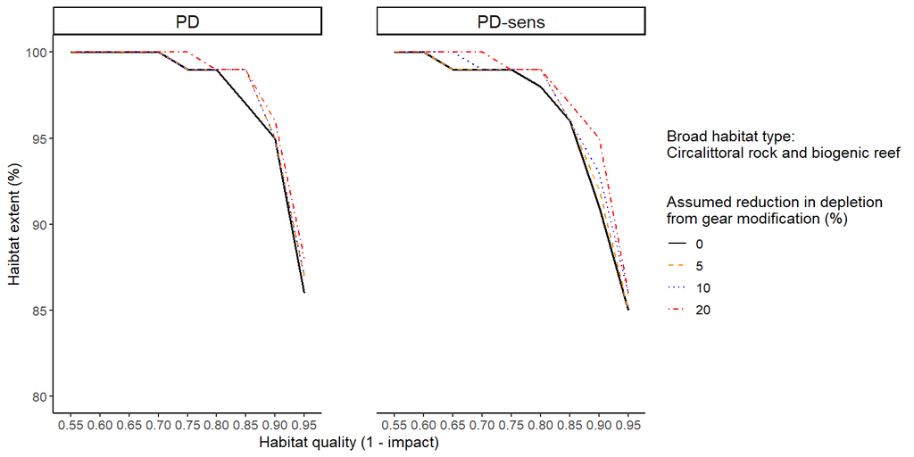

##### Figure 9: Habitat 2

**Figure 9. Effects of gear modifications (5%, 10%, and 20% lower depletion) on the quality-extent relationship for the most abundant MSFD habitat type in the North-Iberian Atlantic subdivision. Habitat quality is defined as 1 - impact, with impact calculated as PD (I‒6a) or PD-sens (I‒7a). The dotted line represent the extent threshold of 75% for the proportion of a broad habitat type that should not be adversely affected (EU, 2024).**

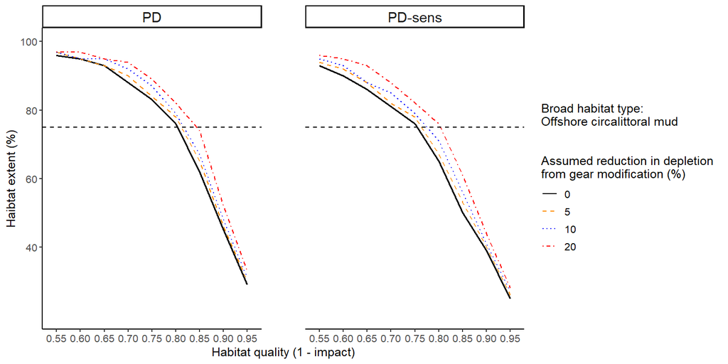

##### Figure 10: Habitat 3

**Figure 10. Effects of gear modifications (5%, 10%, and 20% lower depletion) on the quality-extent relationship for the most abundant MSFD habitat type in the North-Iberian Atlantic subdivision. Habitat quality is defined as 1 - impact, with impact calculated as PD (I‒6a) or PD-sens (I‒7a). The dotted line represent the extent threshold of 75% for the proportion of a broad habitat type that should not be adversely affected (EU, 2024).**

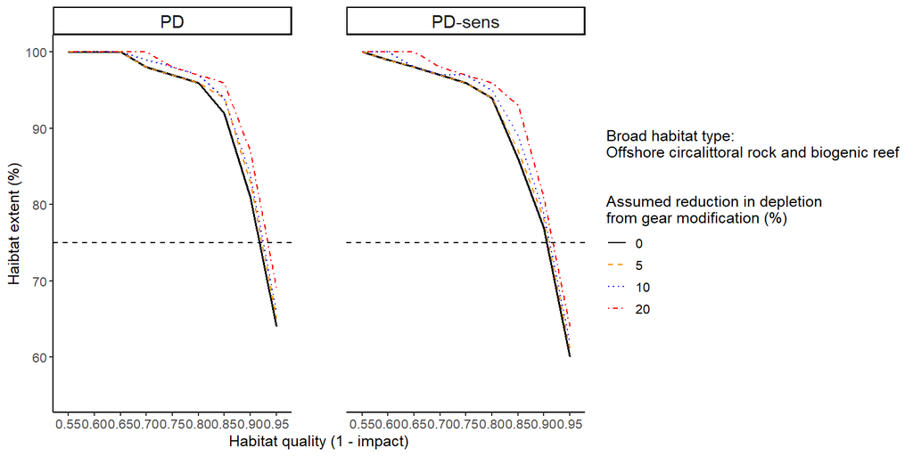

##### Figure 11: Habitat 4

**Figure 11. Effects of gear modifications (5%, 10%, and 20% lower depletion) on the quality-extent relationship for the most abundant MSFD habitat type in the North-Iberian Atlantic subdivision. Habitat quality is defined as 1 - impact, with impact calculated as PD (I‒6a) or PD-sens (I‒7a). The dotted line represent the extent threshold of 75% for the proportion of a broad habitat type that should not be adversely affected (EU, 2024).**

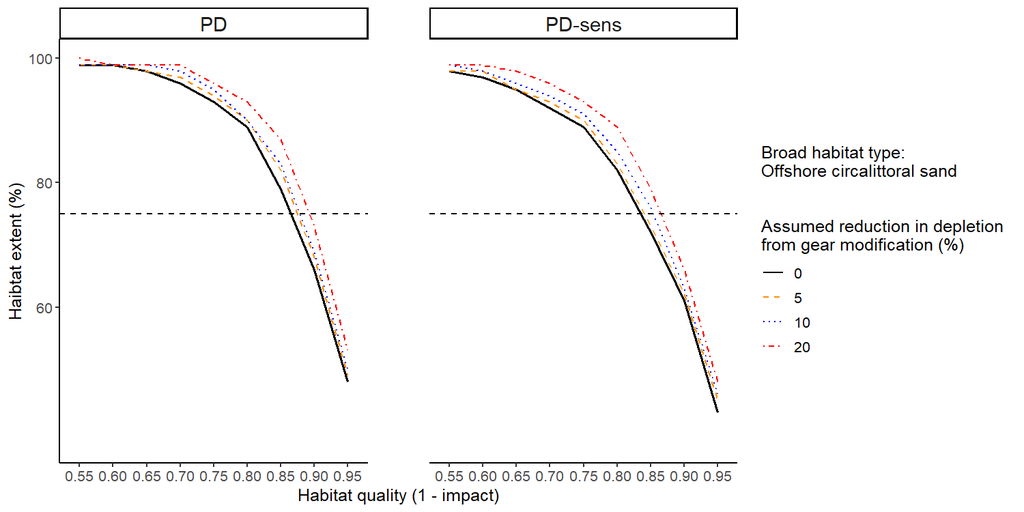